# Week 2 Case Study: Neural Networks & Advanced Backpropagation (template)

**Important:** This notebook is a scaffold. It intentionally omits full solutions. Fill in all `# TODO` sections and replace placeholders as required. Keep cells in order.

## How to use this student template

- Do **not** delete headings or restructure parts. Add code **under** each task.
- Replace placeholders like `YOUR_CODE_HERE` or `YOUR_PATH_HERE`.
- Keep runtime manageable (<15–20 min on Colab GPU).
- Where hints are provided, **do not** copy full working solutions.

**Student:** Tamara Dinneen | **Course:** IT721 Applied Research Topics in Deep Learning | **Week 2 Case Study**

**Dataset:** Red Wine Quality (Cortez et al., 2009), Kaggle `uciml/red-wine-quality-cortez-et-al-2009`: 1,599 wines, 11 physicochemical inputs and a sensory `quality` score.

**Task framing.** Following the template's model builder (a single linear output unit, `loss='mse'`), the networks **regress the quality score**. The split is **stratified on the score**. Models are evaluated with regression metrics (RMSE, MAE, R²) and also with metrics suited to an ordinal score: **quadratic-weighted kappa (QWK)** on the rounded predictions, exact and within-±1 accuracy, and the ROC-AUC of the predicted score for flagging "good" wines (quality ≥ 7).

**Experimental protocol** (from the course guide: *run a baseline, change one parameter, re-run and compare*)

- Each experiment changes **one factor** relative to a stated baseline. Everything else stays fixed: data, batch size 64, seeds, and early-stopping rule.
- Comparisons are repeated over **2 random seeds** and reported as mean ± std.
- All model selection uses the **validation** split. The **test** split is used **once**, in the final evaluation (Part 4.6).
- Figures are numbered and every discussion follows **Observation → Technical reason → Practical impact**.

Runtime: about 15–20 minutes for *Run all* on Colab. Set `FAST = True` in Part 0 for a roughly 5-minute smoke run.

```python
# ---- Part 0: Environment Setup ----
# Install/Import libraries
# !pip install -q numpy pandas matplotlib seaborn scikit-learn tensorflow

import numpy as np, pandas as pd, matplotlib.pyplot as plt, seaborn as sns, random
from sklearn.model_selection import train_test_split
import tensorflow as tf
from tensorflow import keras
from tensorflow.keras import layers

SEED = 42
np.random.seed(SEED)
random.seed(SEED)
tf.random.set_seed(SEED)

# ---- additional imports & settings used in this solution ----
import os, time, math, warnings
warnings.filterwarnings('ignore')
from scipy import stats
from tensorflow.keras import regularizers
from sklearn.model_selection import StratifiedKFold
from sklearn.preprocessing import PowerTransformer, OneHotEncoder
from sklearn.compose import ColumnTransformer
from sklearn.feature_selection import mutual_info_regression
from sklearn.linear_model import Lasso, Ridge
from sklearn.ensemble import RandomForestRegressor
from sklearn.metrics import (mean_squared_error, mean_absolute_error, r2_score, cohen_kappa_score,
                             roc_auc_score, confusion_matrix, roc_curve)

FAST = False                              # True = quick smoke run (1 seed, ~1/3 of the epochs)
SEEDS = [42] if FAST else [42, 7]
def E(n):                                 # epoch budget helper
    return max(5, int(n * (0.35 if FAST else 1.0)))

keras.utils.set_random_seed(SEED)         # seeds python, numpy and TF in one call
tf.get_logger().setLevel('ERROR')          # silence tf.function retracing notices (one model is built per experiment)
pd.set_option('display.float_format', lambda v: f'{v:,.4f}')
pd.set_option('display.max_columns', 40)
sns.set_theme(style='whitegrid', context='notebook')
plt.rcParams.update({'figure.dpi': 80, 'axes.titleweight': 'bold'})
PAL = sns.color_palette('tab10')
T_START = time.time()
print('TensorFlow', tf.__version__, '| GPU:', tf.config.list_physical_devices('GPU'))
```

```
TensorFlow 2.21.0 | GPU: []
```

# Part 1: Data Preparation & Feature Engineering (8 pts)

### Tasks

1. Load the Wine Quality dataset (`winequality-red.csv` or equivalent).
2. Perform statistical analysis of features.
3. Engineer at least one new feature (e.g., ratios, interaction terms).
4. Apply preprocessing: scaling, encoding (if needed), feature selection.
5. Create stratified train/val/test splits.

```python
# Load dataset (local copy / Google Drive first, public mirror of the same Kaggle-UCI file as fallback)
DATA_URL = 'https://raw.githubusercontent.com/plotly/datasets/master/winequality-red.csv'
CANDIDATES = ['winequality-red.csv', '/content/winequality-red.csv',
              '/content/drive/MyDrive/DBA/IT 721 DL/Assignment2/winequality-red.csv']
try:
    from google.colab import drive
    drive.mount('/content/drive')
except Exception:
    pass
path = next((p for p in CANDIDATES if os.path.exists(p)), None)
df_raw = pd.read_csv(path or DATA_URL, encoding='utf-8-sig')
if df_raw.shape[1] == 1:                      # UCI original is ';'-separated
    df_raw = pd.read_csv(path or DATA_URL, sep=';', encoding='utf-8-sig')
df_raw.columns = [c.strip() for c in df_raw.columns]
FEATURES = [c for c in df_raw.columns if c != 'quality']
print('Source:', path or DATA_URL, '| shape:', df_raw.shape)
print('Missing values:', int(df_raw.isna().sum().sum()), '| exact duplicate rows:', int(df_raw.duplicated().sum()))
display(df_raw.head())

# EDA, distributions, correlations -> sections 1.1-1.2 below
# Feature engineering             -> section 1.3
# Scaling / encoding / selection  -> sections 1.5-1.6
# Stratified splits               -> section 1.4
```

```
Source: winequality-red.csv | shape: (1599, 12)
Missing values: 0 | exact duplicate rows: 240
```

|  | fixed acidity | volatile acidity | citric acid | residual sugar | chlorides | free sulfur dioxide | total sulfur dioxide | density | pH | sulphates | alcohol | quality |
| --- | --- | --- | --- | --- | --- | --- | --- | --- | --- | --- | --- | --- |
| 0 | 7.4000 | 0.7000 | 0.0000 | 1.9000 | 0.0760 | 11.0000 | 34.0000 | 0.9978 | 3.5100 | 0.5600 | 9.4000 | 5 |
| 1 | 7.8000 | 0.8800 | 0.0000 | 2.6000 | 0.0980 | 25.0000 | 67.0000 | 0.9968 | 3.2000 | 0.6800 | 9.8000 | 5 |
| 2 | 7.8000 | 0.7600 | 0.0400 | 2.3000 | 0.0920 | 15.0000 | 54.0000 | 0.9970 | 3.2600 | 0.6500 | 9.8000 | 5 |
| 3 | 11.2000 | 0.2800 | 0.5600 | 1.9000 | 0.0750 | 17.0000 | 60.0000 | 0.9980 | 3.1600 | 0.5800 | 9.8000 | 6 |
| 4 | 7.4000 | 0.7000 | 0.0000 | 1.9000 | 0.0760 | 11.0000 | 34.0000 | 0.9978 | 3.5100 | 0.5600 | 9.4000 | 5 |

## 1.1 Dataset overview and target distribution

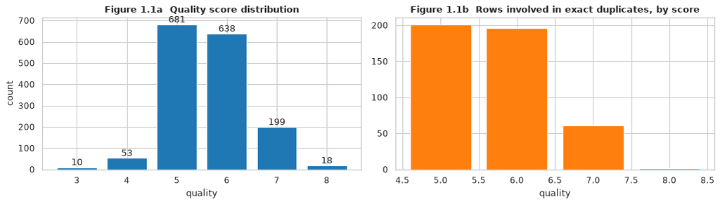

```
float64    11
int64       1
```

```python
fig, ax = plt.subplots(1, 2, figsize=(13, 3.8))
q = df_raw['quality'].value_counts().sort_index()
ax[0].bar(q.index, q.values, color=PAL[0])
for i, v in zip(q.index, q.values): ax[0].text(i, v + 10, str(v), ha='center')
ax[0].set(title='Figure 1.1a  Quality score distribution', xlabel='quality', ylabel='count')
dup_q = df_raw[df_raw.duplicated(keep=False)]['quality'].value_counts().sort_index()
ax[1].bar(dup_q.index, dup_q.values, color=PAL[1])
ax[1].set(title='Figure 1.1b  Rows involved in exact duplicates, by score', xlabel='quality')
plt.tight_layout(); plt.show()
print(df_raw.dtypes.value_counts().to_string())
```

**Observation.** The data has no missing values and all columns are numeric, but **about 15% of rows are exact duplicates**. The target is ordinal and heavily concentrated: scores 5 and 6 account for over 80% of wines, while scores 3 and 8 together make up under 2%. **Reason / impact.** Duplicates that land in both train and test leak information and inflate test scores, so they are removed **before** splitting. The concentration means a model can score a low MSE just by predicting about 5.6 for every wine. Splits are therefore stratified on the score, and metrics that reward getting the extremes right (QWK, R²) are reported alongside RMSE.

## 1.2 Comprehensive statistical analysis of feature distributions

```python
def iqr_outliers(s):
    q1, q3 = s.quantile([.25, .75]); iqr = q3 - q1
    return int(((s < q1 - 1.5 * iqr) | (s > q3 + 1.5 * iqr)).sum())

stat_tbl = df_raw[FEATURES].describe().T
stat_tbl['cv'] = stat_tbl['std'] / stat_tbl['mean']
stat_tbl['skew'] = df_raw[FEATURES].skew()
stat_tbl['kurtosis'] = df_raw[FEATURES].kurt()
stat_tbl['normaltest_p'] = [stats.normaltest(df_raw[c])[1] for c in FEATURES]      # D'Agostino-Pearson
stat_tbl['outlier_%(IQR)'] = [100 * iqr_outliers(df_raw[c]) / len(df_raw) for c in FEATURES]
stat_tbl['spearman_vs_quality'] = [stats.spearmanr(df_raw[c], df_raw['quality'])[0] for c in FEATURES]
stat_tbl['kruskal_p(across scores)'] = [stats.kruskal(*[g[c].values for _, g in df_raw.groupby('quality')])[1] for c in FEATURES]
stat_tbl.sort_values('skew', ascending=False)
```

|  | count | mean | std | min | 25% | 50% | 75% | max | cv | skew | kurtosis | normaltest_p | outlier_%(IQR) | spearman_vs_quality | kruskal_p(across scores) |
| --- | --- | --- | --- | --- | --- | --- | --- | --- | --- | --- | --- | --- | --- | --- | --- |
| chlorides | 1,599.0000 | 0.0875 | 0.0471 | 0.0120 | 0.0700 | 0.0790 | 0.0900 | 0.6110 | 0.5381 | 5.6803 | 41.7158 | 0.0000 | 7.0044 | -0.1899 | 0.0000 |
| residual sugar | 1,599.0000 | 2.5388 | 1.4099 | 0.9000 | 1.9000 | 2.2000 | 2.6000 | 15.5000 | 0.5554 | 4.5407 | 28.6176 | 0.0000 | 9.6936 | 0.0320 | 0.2339 |
| sulphates | 1,599.0000 | 0.6581 | 0.1695 | 0.3300 | 0.5500 | 0.6200 | 0.7300 | 2.0000 | 0.2576 | 2.4287 | 11.7203 | 0.0000 | 3.6898 | 0.3771 | 0.0000 |
| total sulfur dioxide | 1,599.0000 | 46.4678 | 32.8953 | 6.0000 | 22.0000 | 38.0000 | 62.0000 | 289.0000 | 0.7079 | 1.5155 | 3.8098 | 0.0000 | 3.4396 | -0.1967 | 0.0000 |
| free sulfur dioxide | 1,599.0000 | 15.8749 | 10.4602 | 1.0000 | 7.0000 | 14.0000 | 21.0000 | 72.0000 | 0.6589 | 1.2506 | 2.0236 | 0.0000 | 1.8762 | -0.0569 | 0.0000 |
| fixed acidity | 1,599.0000 | 8.3196 | 1.7411 | 4.6000 | 7.1000 | 7.9000 | 9.2000 | 15.9000 | 0.2093 | 0.9828 | 1.1321 | 0.0000 | 3.0644 | 0.1141 | 0.0000 |
| alcohol | 1,599.0000 | 10.4230 | 1.0657 | 8.4000 | 9.5000 | 10.2000 | 11.1000 | 14.9000 | 0.1022 | 0.8608 | 0.2000 | 0.0000 | 0.8130 | 0.4785 | 0.0000 |
| volatile acidity | 1,599.0000 | 0.5278 | 0.1791 | 0.1200 | 0.3900 | 0.5200 | 0.6400 | 1.5800 | 0.3392 | 0.6716 | 1.2255 | 0.0000 | 1.1882 | -0.3806 | 0.0000 |
| citric acid | 1,599.0000 | 0.2710 | 0.1948 | 0.0000 | 0.0900 | 0.2600 | 0.4200 | 1.0000 | 0.7189 | 0.3183 | -0.7890 | 0.0000 | 0.0625 | 0.2135 | 0.0000 |
| pH | 1,599.0000 | 3.3111 | 0.1544 | 2.7400 | 3.2100 | 3.3100 | 3.4000 | 4.0100 | 0.0466 | 0.1937 | 0.8069 | 0.0000 | 2.1889 | -0.0437 | 0.0002 |
| density | 1,599.0000 | 0.9967 | 0.0019 | 0.9901 | 0.9956 | 0.9968 | 0.9978 | 1.0037 | 0.0019 | 0.0713 | 0.9341 | 0.0000 | 2.8143 | -0.1771 | 0.0000 |

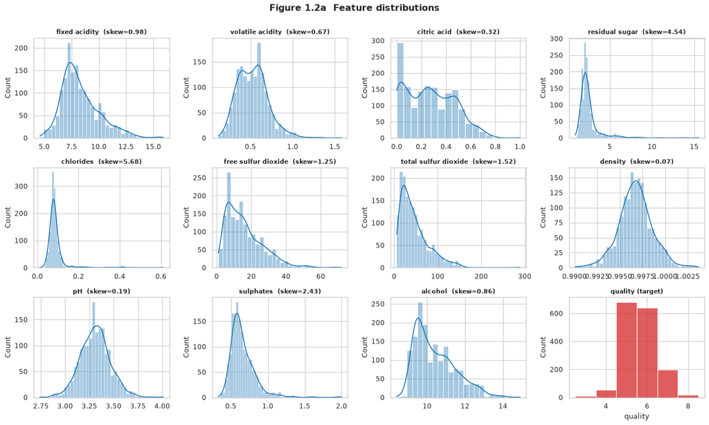

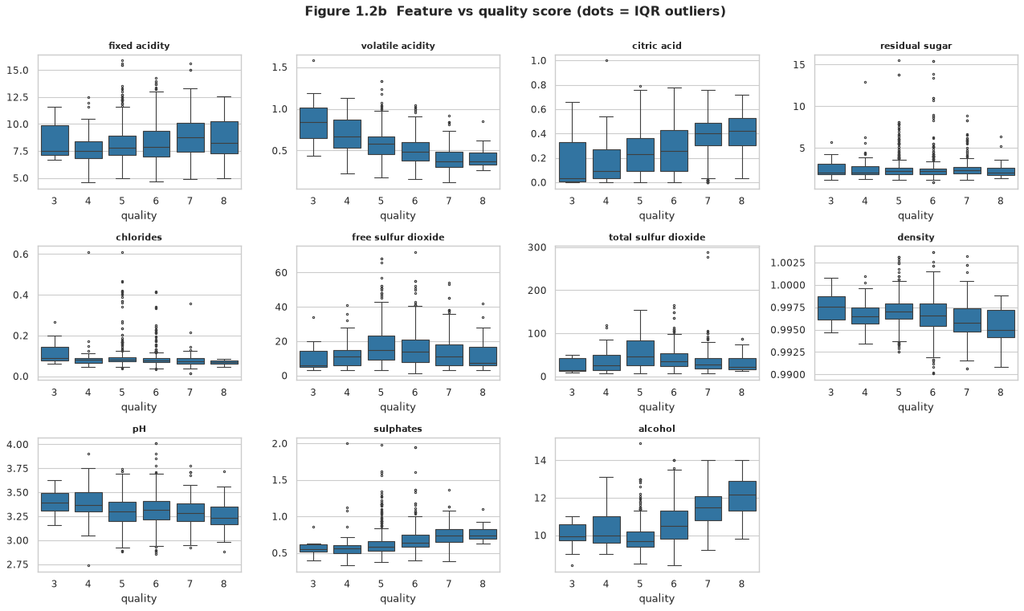

```python
fig, axes = plt.subplots(3, 4, figsize=(16, 9.5))
for ax, c in zip(axes.ravel(), FEATURES):
    sns.histplot(df_raw[c], kde=True, ax=ax, color=PAL[0], alpha=.4)
    ax.set_title(f'{c}  (skew={df_raw[c].skew():.2f})', fontsize=10); ax.set_xlabel('')
ax = axes.ravel()[-1]; sns.histplot(df_raw['quality'], discrete=True, ax=ax, color=PAL[3]); ax.set_title('quality (target)', fontsize=10)
plt.suptitle('Figure 1.2a  Feature distributions', y=1.0, fontsize=14, weight='bold'); plt.tight_layout(); plt.show()

fig, axes = plt.subplots(3, 4, figsize=(16, 9.5))
for ax, c in zip(axes.ravel(), FEATURES):
    sns.boxplot(data=df_raw, x='quality', y=c, ax=ax, color=PAL[0], fliersize=2); ax.set_title(c, fontsize=10); ax.set_ylabel('')
axes.ravel()[-1].axis('off')
plt.suptitle('Figure 1.2b  Feature vs quality score (dots = IQR outliers)', y=1.0, fontsize=14, weight='bold'); plt.tight_layout(); plt.show()
```

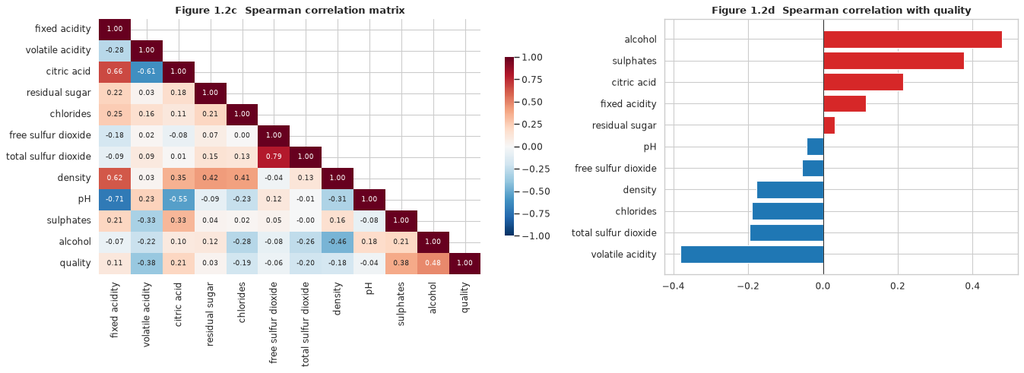

```python
fig, ax = plt.subplots(1, 2, figsize=(17, 6.3), gridspec_kw={'width_ratios': [1.35, 1]})
corr = df_raw.corr(method='spearman')
sns.heatmap(corr, mask=np.triu(np.ones_like(corr, dtype=bool), 1), annot=True, fmt='.2f', cmap='RdBu_r', center=0,
            vmin=-1, vmax=1, ax=ax[0], annot_kws={'size': 8}, cbar_kws={'shrink': .7})
ax[0].set_title('Figure 1.2c  Spearman correlation matrix')
qc = corr['quality'].drop('quality').sort_values()
ax[1].barh(qc.index, qc.values, color=[PAL[3] if v > 0 else PAL[0] for v in qc.values]); ax[1].axvline(0, c='k', lw=.8)
ax[1].set_title('Figure 1.2d  Spearman correlation with quality'); plt.tight_layout(); plt.show()
```

## 1.3 Domain-driven feature engineering

Every engineered feature is a **row-wise** function of that wine's own measurements, so it cannot leak information between splits.

| Feature | Formula | Domain rationale |
| --- | --- | --- |
| `total_acidity` | fixed + volatile + citric | overall perceived sourness |
| `fixed_to_volatile` | fixed / volatile | tartaric ("good") acid vs acetic (spoilage) acid |
| `free_so2_ratio` | free SO₂ / total SO₂ | share of SO₂ that is still active |
| `molecular_so2` | free SO₂ / (1 + 10^(pH − 1.81)) | the antimicrobial molecular form depends on pH (pKa ≈ 1.81); winemakers target about 0.5–0.8 mg/L |
| `bound_so2` | total − free SO₂ | SO₂ bound to acetaldehyde; an oxidation marker |
| `alcohol_x_sulphates` | alcohol × sulphates | interaction of the two strongest positive signals |
| `sugar_to_alcohol` | residual sugar / alcohol | completeness of fermentation / sweetness balance |
| `acid_to_alcohol` | total acidity / alcohol | the structural balance between acid and alcohol |
| `alcohol_band` *(categorical)* | low < 10% ≤ medium < 11.5% ≤ high | a wine-trade style band, used to demonstrate categorical encoding |

```python
def engineer_features(d):
    d = d.copy()
    d['total_acidity'] = d['fixed acidity'] + d['volatile acidity'] + d['citric acid']
    d['fixed_to_volatile'] = d['fixed acidity'] / d['volatile acidity']
    d['free_so2_ratio'] = d['free sulfur dioxide'] / d['total sulfur dioxide']
    d['molecular_so2'] = d['free sulfur dioxide'] / (1 + 10 ** (d['pH'] - 1.81))
    d['bound_so2'] = d['total sulfur dioxide'] - d['free sulfur dioxide']
    d['alcohol_x_sulphates'] = d['alcohol'] * d['sulphates']
    d['sugar_to_alcohol'] = d['residual sugar'] / d['alcohol']
    d['acid_to_alcohol'] = d['total_acidity'] / d['alcohol']
    d['alcohol_band'] = pd.cut(d['alcohol'], [0, 10, 11.5, 100], right=False, labels=['low', 'medium', 'high']).astype(str)
    return d

df = engineer_features(df_raw.drop_duplicates().reset_index(drop=True))   # de-duplicate BEFORE splitting
print(f'Rows after de-duplication: {len(df)} (removed {len(df_raw) - len(df)})')
ENG = ['total_acidity', 'fixed_to_volatile', 'free_so2_ratio', 'molecular_so2', 'bound_so2',
       'alcohol_x_sulphates', 'sugar_to_alcohol', 'acid_to_alcohol']
NUMERIC, CATEGORICAL = FEATURES + ENG, ['alcohol_band']

sig = pd.DataFrame({'spearman_vs_quality': [stats.spearmanr(df[c], df['quality'])[0] for c in NUMERIC],
                    'type': ['original'] * len(FEATURES) + ['engineered'] * len(ENG)}, index=NUMERIC)
sig['abs_rho'] = sig['spearman_vs_quality'].abs()
display(sig.sort_values('abs_rho', ascending=False).head(10))
print(df.groupby('alcohol_band')['quality'].agg(['count', 'mean']).reindex(['low', 'medium', 'high']).round(3))
```

```
Rows after de-duplication: 1359 (removed 240)
```

|  | spearman_vs_quality | type | abs_rho |
| --- | --- | --- | --- |
| alcohol_x_sulphates | 0.4920 | engineered | 0.4920 |
| alcohol | 0.4880 | original | 0.4880 |
| volatile acidity | -0.3874 | original | 0.3874 |
| sulphates | 0.3806 | original | 0.3806 |
| fixed_to_volatile | 0.3460 | engineered | 0.3460 |
| bound_so2 | -0.2311 | engineered | 0.2311 |
| free_so2_ratio | 0.2238 | engineered | 0.2238 |
| citric acid | 0.2194 | original | 0.2194 |
| chlorides | -0.2044 | original | 0.2044 |
| total sulfur dioxide | -0.1966 | original | 0.1966 |

```
              count   mean
alcohol_band
low             576 5.2450
medium          536 5.7010
high            247 6.3360
```

## 1.4 Stratified train / validation / test split (70 / 15 / 15)

The split is stratified on the quality score, so every split keeps the same share of each score, including the rare 3s and 8s.

```python
idx = np.arange(len(df))
tr_idx, tmp_idx = train_test_split(idx, test_size=0.30, stratify=df['quality'], random_state=SEED)
va_idx, te_idx = train_test_split(tmp_idx, test_size=0.50, stratify=df['quality'].iloc[tmp_idx], random_state=SEED)
df_tr, df_va, df_te = df.iloc[tr_idx], df.iloc[va_idx], df.iloc[te_idx]
y_train, y_val, y_test = (d['quality'].values.astype('float32') for d in (df_tr, df_va, df_te))
pd.DataFrame({n: {'n': len(d), 'mean_quality': d['quality'].mean(), **{f'share q={k}': (d['quality'] == k).mean()
             for k in sorted(df.quality.unique())}} for n, d in [('train', df_tr), ('validation', df_va), ('test', df_te)]}).T
```

|  | n | mean_quality | share q=3 | share q=4 | share q=5 | share q=6 | share q=7 | share q=8 |
| --- | --- | --- | --- | --- | --- | --- | --- | --- |
| train | 951.0000 | 5.6236 | 0.0074 | 0.0389 | 0.4248 | 0.3933 | 0.1230 | 0.0126 |
| validation | 204.0000 | 5.6324 | 0.0049 | 0.0392 | 0.4265 | 0.3922 | 0.1225 | 0.0147 |
| test | 204.0000 | 5.6127 | 0.0098 | 0.0392 | 0.4216 | 0.3971 | 0.1225 | 0.0098 |

## 1.5 Advanced preprocessing: transformation, scaling and encoding (fit on train only)

- **Numeric:** `PowerTransformer('yeo-johnson', standardize=True)`. This removes skew, then centres and scales each feature, and it handles zeros such as `citric acid = 0`, which Box–Cox and log transforms cannot.
- **Categorical:** `OneHotEncoder(handle_unknown='ignore')` for `alcohol_band`.
- Both transformers are fit on **train only** and then applied to validation and test, so no information leaks from the held-out data.

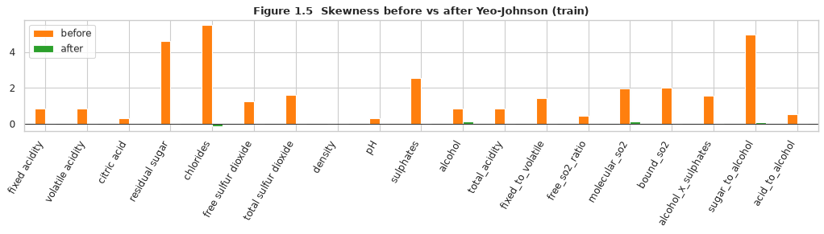

```
Mean |skew| before = 1.71, after = 0.04
```

```python
def make_preprocessor():
    return ColumnTransformer([('num', PowerTransformer(method='yeo-johnson', standardize=True), NUMERIC),
                              ('cat', OneHotEncoder(handle_unknown='ignore', sparse_output=False), CATEGORICAL)])

pre = make_preprocessor().fit(df_tr)
ALL_FEATS = NUMERIC + [f'alcohol_band_{c}' for c in pre.named_transformers_['cat'].categories_[0]]
to_df = lambda d, p=pre: pd.DataFrame(p.transform(d), columns=ALL_FEATS, index=d.index)
Xtr_df, Xva_df, Xte_df = to_df(df_tr), to_df(df_va), to_df(df_te)

skew_cmp = pd.DataFrame({'before': df_tr[NUMERIC].skew(), 'after': Xtr_df[NUMERIC].skew()})
ax = skew_cmp.plot.bar(figsize=(13, 3.8), color=[PAL[1], PAL[2]]); ax.axhline(0, c='k', lw=.8)
ax.set_title('Figure 1.5  Skewness before vs after Yeo-Johnson (train)'); plt.xticks(rotation=60, ha='right'); plt.tight_layout(); plt.show()
print(f"Mean |skew| before = {skew_cmp['before'].abs().mean():.2f}, after = {skew_cmp['after'].abs().mean():.2f}")
```

## 1.6 Feature selection

A three-stage procedure, run on the training set only:

1. **Relevance:** mutual information with the quality score, which captures non-linear dependence.
2. **Redundancy:** for every pair with |r| > 0.85, drop the member with the lower mutual information.
3. **Embedded check:** an L1 (lasso) regression. A feature is kept if it survives step 2 **and** shows relevance (MI ≥ 0.01 **or** a non-zero lasso coefficient).

The result is checked against a ridge-regression baseline on the validation set, and multicollinearity is measured with the variance inflation factor (VIF).

```python
mi = pd.Series(mutual_info_regression(Xtr_df, y_train, random_state=SEED,
               discrete_features=[c.startswith('alcohol_band') for c in ALL_FEATS]), index=ALL_FEATS)
l1 = pd.Series(Lasso(alpha=0.01, max_iter=20000).fit(Xtr_df, y_train).coef_, index=ALL_FEATS)
cabs = Xtr_df.corr().abs(); redundant = set()
for i, a in enumerate(ALL_FEATS):
    for b in ALL_FEATS[i + 1:]:
        if cabs.loc[a, b] > 0.85 and not {a, b} & redundant:
            redundant.add(a if mi[a] < mi[b] else b)
SELECTED = [f for f in ALL_FEATS if f not in redundant and (mi[f] >= 0.01 or abs(l1[f]) > 1e-6)]

vif = lambda X: pd.Series(np.diag(np.linalg.pinv(np.corrcoef(X, rowvar=False))), index=X.columns)
num_all = [c for c in ALL_FEATS if not c.startswith('alcohol_band')]
num_sel = [c for c in SELECTED if not c.startswith('alcohol_band')]
sel = pd.DataFrame({'mutual_info': mi, 'lasso_coef': l1, 'redundant': [f in redundant for f in ALL_FEATS],
                    'selected': [f in SELECTED for f in ALL_FEATS],
                    'VIF_all': vif(Xtr_df[num_all]).reindex(ALL_FEATS), 'VIF_selected': vif(Xtr_df[num_sel]).reindex(ALL_FEATS)})
display(sel.sort_values('mutual_info', ascending=False))
print(f'Selected {len(SELECTED)}/{len(ALL_FEATS)}:', SELECTED)
print('Dropped (redundant):', sorted(redundant), '| dropped (irrelevant):', sorted(set(ALL_FEATS) - set(SELECTED) - redundant))

def ridge_val_rmse(cols):
    m = Ridge(1.0).fit(Xtr_df[cols], y_train); return mean_squared_error(y_val, m.predict(Xva_df[cols])) ** .5
print(f'Ridge validation RMSE | 11 original: {ridge_val_rmse(FEATURES):.4f} | all {len(ALL_FEATS)}: '
      f'{ridge_val_rmse(ALL_FEATS):.4f} | selected {len(SELECTED)}: {ridge_val_rmse(SELECTED):.4f}')
```

|  | mutual_info | lasso_coef | redundant | selected | VIF_all | VIF_selected |
| --- | --- | --- | --- | --- | --- | --- |
| alcohol | 0.1922 | 0.2297 | False | True | 30.9347 | 2.5857 |
| alcohol_x_sulphates | 0.1617 | 0.0000 | False | True | 112.0974 | 1.8347 |
| fixed_to_volatile | 0.1219 | 0.1964 | False | True | 1,119.9726 | 2.9019 |
| volatile acidity | 0.0920 | -0.0135 | True | False | 597.1047 | NaN |
| density | 0.0767 | -0.0683 | False | True | 7.9982 | 7.1942 |
| sugar_to_alcohol | 0.0756 | -0.0000 | False | True | 66.2791 | 2.0231 |
| sulphates | 0.0726 | 0.1822 | True | False | 83.7730 | NaN |
| bound_so2 | 0.0588 | -0.0151 | False | True | 119.3564 | 59.4000 |
| molecular_so2 | 0.0556 | -0.0000 | False | True | 116.7877 | 45.2094 |
| citric acid | 0.0516 | -0.0000 | False | True | 18.9971 | 3.4843 |
| total sulfur dioxide | 0.0483 | -0.0000 | True | False | 87.1512 | NaN |
| acid_to_alcohol | 0.0478 | -0.0000 | False | True | 98.3793 | 10.4300 |
| fixed acidity | 0.0464 | 0.0000 | True | False | 1,677.5553 | NaN |
| residual sugar | 0.0461 | 0.0000 | True | False | 58.4747 | NaN |
| free_so2_ratio | 0.0385 | 0.0299 | False | True | 99.7017 | 43.0955 |
| free sulfur dioxide | 0.0235 | -0.0000 | True | False | 239.2838 | NaN |
| chlorides | 0.0152 | -0.0515 | False | True | 1.4679 | 1.4157 |
| pH | 0.0126 | -0.0119 | False | True | 27.7576 | 12.7744 |
| total_acidity | 0.0000 | 0.0000 | True | False | 1,115.5553 | NaN |
| alcohol_band_high | 0.0000 | 0.1238 | False | True | NaN | NaN |
| alcohol_band_low | 0.0000 | -0.0000 | False | False | NaN | NaN |
| alcohol_band_medium | 0.0000 | -0.0000 | False | False | NaN | NaN |

```
Selected 13/22: ['citric acid', 'chlorides', 'density', 'pH', 'alcohol', 'fixed_to_volatile', 'free_so2_ratio', 'molecular_so2', 'bound_so2', 'alcohol_x_sulphates', 'sugar_to_alcohol', 'acid_to_alcohol', 'alcohol_band_high']
Dropped (redundant): ['fixed acidity', 'free sulfur dioxide', 'residual sugar', 'sulphates', 'total sulfur dioxide', 'total_acidity', 'volatile acidity'] | dropped (irrelevant): ['alcohol_band_low', 'alcohol_band_medium']
Ridge validation RMSE | 11 original: 0.6544 | all 22: 0.6379 | selected 13: 0.6448
```

```python
X_train, X_val, X_test = (d[SELECTED].values.astype('float32') for d in (Xtr_df, Xva_df, Xte_df))
N_FEAT, Y_MEAN = X_train.shape[1], float(y_train.mean())

def reg_metrics(y, p):
    p = np.asarray(p, dtype='float64').ravel()
    if not np.all(np.isfinite(p)):
        return dict(rmse=np.nan, mae=np.nan, r2=np.nan, qwk=np.nan, exact=np.nan, within1=np.nan, good_auc=np.nan)
    r = np.clip(np.rint(p), 3, 8).astype(int); yi = y.astype(int)
    return dict(rmse=mean_squared_error(y, p) ** .5, mae=mean_absolute_error(y, p), r2=r2_score(y, p),
                qwk=cohen_kappa_score(yi, r, weights='quadratic'), exact=float(np.mean(r == yi)),
                within1=float(np.mean(np.abs(r - yi) <= 1)), good_auc=roc_auc_score(yi >= 7, p))

BASELINES = {'Predict train mean': reg_metrics(y_val, np.full_like(y_val, Y_MEAN))}
for n, m in [('Ridge regression', Ridge(1.0)),
             ('Random forest (500 trees)', RandomForestRegressor(500, min_samples_leaf=2, random_state=SEED, n_jobs=-1))]:
    BASELINES[n] = reg_metrics(y_val, m.fit(X_train, y_train).predict(X_val))
print('X_train', X_train.shape, 'X_val', X_val.shape, 'X_test', X_test.shape)
pd.DataFrame(BASELINES).T
```

```
X_train (951, 13) X_val (204, 13) X_test (204, 13)
```

|  | rmse | mae | r2 | qwk | exact | within1 | good_auc |
| --- | --- | --- | --- | --- | --- | --- | --- |
| Predict train mean | 0.8208 | 0.6937 | -0.0001 | 0.0000 | 0.3922 | 0.9412 | 0.5000 |
| Ridge regression | 0.6448 | 0.5054 | 0.3828 | 0.5001 | 0.5833 | 0.9657 | 0.8689 |
| Random forest (500 trees) | 0.6376 | 0.5002 | 0.3965 | 0.4948 | 0.5686 | 0.9657 | 0.8640 |

# Part 2: Gradient Flow Analysis (12 pts)

### Tasks

1. Build models with depths: 3, 6, 9, 12 layers.
2. Write a custom callback to record gradient norms.
3. Visualize gradient magnitudes layer-wise.
4. Identify patterns of vanishing/exploding gradients.

```python
# Model builder function (template signature kept; extra options are used in Parts 2-4)
def make_activation(name, i):
    if name == 'relu':       return layers.ReLU(name=f'act_{i}')
    if name == 'leaky_relu': return layers.LeakyReLU(negative_slope=0.1, name=f'act_{i}')
    if name == 'elu':        return layers.ELU(name=f'act_{i}')
    return layers.Activation(name, name=f'act_{i}')            # swish, selu, tanh, sigmoid

def make_init(init):            # strings -> fresh Keras initialiser; callables are factories
    return keras.initializers.get(init) if isinstance(init, str) else init()

def make_reg(reg):
    if reg is None: return None
    kind, *v = reg
    return {'l1': lambda: regularizers.L1(v[0]), 'l2': lambda: regularizers.L2(v[0]),
            'l1l2': lambda: regularizers.L1L2(l1=v[0], l2=v[1])}[kind]()

def build_deep_model(input_dim, depth=3, units=64, activation='relu', init='he_normal', norm=None,
                     dropout=0.0, dropout_positions='all', input_dropout=0.0, reg=None):
    model = keras.Sequential(name=f'mlp_d{depth}')
    model.add(layers.Input(shape=(input_dim,)))
    if input_dropout: model.add(layers.Dropout(input_dropout, name='input_dropout'))
    for i in range(1, depth + 1):
        model.add(layers.Dense(units, kernel_initializer=make_init(init), kernel_regularizer=make_reg(reg),
                               use_bias=(norm != 'batch'), name=f'dense_{i}'))
        if norm == 'batch': model.add(layers.BatchNormalization(name=f'bn_{i}'))
        if norm == 'layer': model.add(layers.LayerNormalization(name=f'ln_{i}'))
        model.add(make_activation(activation, i))
        use_do = {'all': True, 'early': i <= depth // 2, 'late': i > depth // 2}[dropout_positions]
        if dropout > 0 and use_do: model.add(layers.Dropout(dropout, name=f'dropout_{i}'))
    # regression task: one linear unit; bias starts at the training mean so all models begin from the same baseline
    model.add(layers.Dense(1, bias_initializer=keras.initializers.Constant(Y_MEAN), name='output'))
    return model

# Custom callback to log gradients (GradientTape inside a tf.function)
class GradientNormCallback(keras.callbacks.Callback):
    # Records the L2 norm of dLoss/dKernel for every Dense layer on a fixed probe set,
    # once before training (epoch 0) and after every epoch.
    def __init__(self, X, y):
        super().__init__()
        self.X, self.y = tf.constant(X), tf.constant(np.asarray(y, 'float32').reshape(-1, 1))
        self.records, self.names, self._fn = [], None, None

    def _build(self):
        dense = [l for l in self.model.layers if isinstance(l, layers.Dense)]
        self.names, kernels, mse = [l.name for l in dense], [l.kernel for l in dense], keras.losses.MeanSquaredError()
        @tf.function
        def grad_norms(X, y):
            with tf.GradientTape() as tape:
                loss = mse(y, self.model(X, training=True))
            return [tf.norm(g) for g in tape.gradient(loss, kernels)]
        self._fn = grad_norms

    def _log(self):
        self.records.append([float(v) for v in self._fn(self.X, self.y)])

    def on_train_begin(self, logs=None):
        self._build(); self._log()
    def on_epoch_end(self, epoch, logs=None):
        self._log()
    def frame(self):            # rows: epoch (0 = initialisation); columns: dense_1 ... output
        return pd.DataFrame(self.records, columns=self.names)

class LRLogger(keras.callbacks.Callback):
    def on_train_begin(self, logs=None): self.lrs = []
    def on_epoch_end(self, epoch, logs=None): self.lrs.append(float(np.asarray(self.model.optimizer.learning_rate)))

def make_ds(X, y, batch_size=64, train=True):
    # cached tf.data pipeline (reshuffled every epoch) -- ~2-3x faster than feeding NumPy arrays to fit()
    ds = tf.data.Dataset.from_tensor_slices((X, np.asarray(y, 'float32'))).cache()
    if train: ds = ds.shuffle(len(X))
    return ds.batch(batch_size if train else 4096).prefetch(tf.data.AUTOTUNE)

def predict(model, X):          # direct call: much faster than model.predict() for small in-memory arrays
    return model(X, training=False).numpy().ravel()

VAL_DS = make_ds(X_val, y_val, train=False)
build_deep_model(N_FEAT, depth=3).summary()
```

```
Model: "mlp_d3"
```

```
┏━━━━━━━━━━━━━━━━━━━━━━━━━━━━━━━━━┳━━━━━━━━━━━━━━━━━━━━━━━━┳━━━━━━━━━━━━━━━┓
┃ Layer (type)                    ┃ Output Shape           ┃       Param # ┃
┡━━━━━━━━━━━━━━━━━━━━━━━━━━━━━━━━━╇━━━━━━━━━━━━━━━━━━━━━━━━╇━━━━━━━━━━━━━━━┩
│ dense_1 (Dense)                 │ (None, 64)             │           896 │
├─────────────────────────────────┼────────────────────────┼───────────────┤
│ act_1 (ReLU)                    │ (None, 64)             │             0 │
├─────────────────────────────────┼────────────────────────┼───────────────┤
│ dense_2 (Dense)                 │ (None, 64)             │         4,160 │
├─────────────────────────────────┼────────────────────────┼───────────────┤
│ act_2 (ReLU)                    │ (None, 64)             │             0 │
├─────────────────────────────────┼────────────────────────┼───────────────┤
│ dense_3 (Dense)                 │ (None, 64)             │         4,160 │
├─────────────────────────────────┼────────────────────────┼───────────────┤
│ act_3 (ReLU)                    │ (None, 64)             │             0 │
├─────────────────────────────────┼────────────────────────┼───────────────┤
│ output (Dense)                  │ (None, 1)              │            65 │
└─────────────────────────────────┴────────────────────────┴───────────────┘
```

```
 Total params: 9,281 (36.25 KB)
```

```
 Trainable params: 9,281 (36.25 KB)
```

```
 Non-trainable params: 0 (0.00 B)
```

## 2.1 Experiment design: depths 3, 6, 9 and 12

`build_deep_model` (above) builds each hidden block as `Dense → [norm] → activation → [dropout]`, so activations can be probed by name. `GradientNormCallback` is the required **custom callback**: before training and after every epoch it runs `tf.GradientTape` (compiled with `tf.function`) on a fixed probe set, the whole training set. It logs ‖∂L/∂W‖ for every layer, from layer 1 (input side) to the output layer. Because the probe set is fixed, the measurements are free of mini-batch noise and comparable across epochs.

Each depth is trained in **three regimes**. Within a regime, depth is the only factor that changes.

| Regime | Activation | Initialisation | Hypothesis |
| --- | --- | --- | --- |
| A | sigmoid | Xavier/Glorot | **vanishing**: σ′ ≤ 0.25, so the gradient shrinks at least 4× per layer |
| B | ReLU | He normal | **healthy**: the derivative is 1 on active paths, and He scaling preserves variance |
| C | ReLU | N(0, 0.5²), about 2.8× He's std | **exploding**: variance grows about 8× per layer |

All runs use SGD with momentum (lr = 0.01, momentum = 0.9) for 40 epochs. Plain SGD is used deliberately: adaptive optimisers rescale gradients and would hide the raw magnitudes. `TerminateOnNaN` stops runs that diverge.

```python
DEPTHS, EP_G = [3, 6, 9, 12], E(40)
REGIMES = {'A. sigmoid + Xavier': dict(activation='sigmoid', init='glorot_uniform'),
           'B. ReLU + He': dict(activation='relu', init='he_normal'),
           'C. ReLU + N(0,0.5)': dict(activation='relu', init=lambda: keras.initializers.RandomNormal(stddev=0.5))}

def grad_experiment(kw, depth, opt=None, extra=None, epochs=EP_G):
    keras.utils.set_random_seed(SEED)
    model = build_deep_model(N_FEAT, depth=depth, **kw, **(extra or {}))
    model.compile(optimizer=opt() if opt else keras.optimizers.SGD(0.01, momentum=0.9), loss='mse',
                  metrics=[keras.metrics.RootMeanSquaredError(name='rmse')], steps_per_execution=16)
    cb = GradientNormCallback(X_train, y_train)
    h = model.fit(make_ds(X_train, y_train), validation_data=VAL_DS, epochs=epochs, verbose=0,
                  callbacks=[cb, keras.callbacks.TerminateOnNaN()])
    return dict(grads=cb.frame(), hist=pd.DataFrame(h.history), val=reg_metrics(y_val, predict(model, X_val)),
                diverged=not np.isfinite(h.history['loss'][-1]), epochs=len(h.history['loss']))

t0 = time.time()
GR = {(r, d): grad_experiment(kw, d) for r, kw in REGIMES.items() for d in DEPTHS}
print(f'{len(GR)} runs in {time.time() - t0:.0f}s')
```

```
Batch 15: Invalid loss, terminating training
```

```
Batch 15: Invalid loss, terminating training
```

```
Batch 15: Invalid loss, terminating training
```

```
Batch 15: Invalid loss, terminating training
```

```
Batch 15: Invalid loss, terminating training
```

```
Batch 15: Invalid loss, terminating training
```

```
12 runs in 28s
```

## 2.2 Visualising gradient flow through the layers

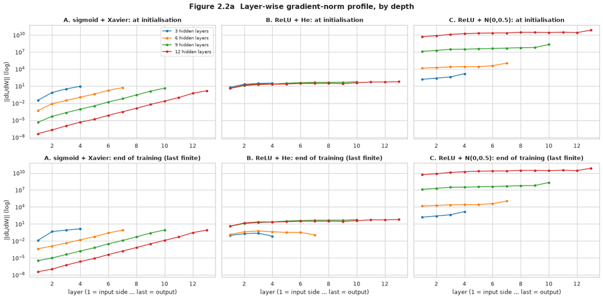

```python
fig, axes = plt.subplots(2, 3, figsize=(17, 8.5), sharey='row')
for j, r in enumerate(REGIMES):
    for k, d in enumerate(DEPTHS):
        g = GR[(r, d)]['grads']; x = np.arange(1, g.shape[1] + 1)
        fin = g[np.isfinite(g).all(axis=1)]
        axes[0, j].semilogy(x, g.iloc[0], '-o', ms=4, color=PAL[k], label=f'{d} hidden layers')
        axes[1, j].semilogy(x, fin.iloc[-1], '-o', ms=4, color=PAL[k], label=f'{d} hidden layers')
    axes[0, j].set_title(f'{r}: at initialisation'); axes[1, j].set_title(f'{r}: end of training (last finite)')
    axes[1, j].set_xlabel('layer (1 = input side ... last = output)')
for a in axes[:, 0]: a.set_ylabel('||dL/dW|| (log)')
axes[0, 0].legend(fontsize=9)
plt.suptitle('Figure 2.2a  Layer-wise gradient-norm profile, by depth', fontsize=14, weight='bold'); plt.tight_layout(); plt.show()
```

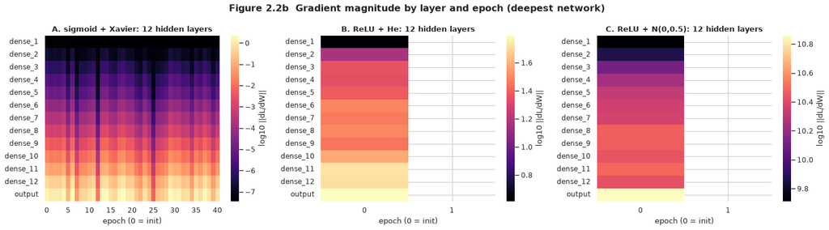

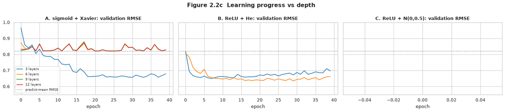

```python
fig, axes = plt.subplots(1, 3, figsize=(18, 5))
for ax, r in zip(axes, REGIMES):
    g = GR[(r, 12)]['grads']
    sns.heatmap(np.log10(g.T.replace(0, np.nan).astype(float)), ax=ax, cmap='magma', cbar_kws={'label': 'log10 ||dL/dW||'},
                xticklabels=max(1, len(g) // 8))
    ax.set(title=f'{r}: 12 hidden layers', xlabel='epoch (0 = init)', ylabel='')
plt.suptitle('Figure 2.2b  Gradient magnitude by layer and epoch (deepest network)', fontsize=14, weight='bold')
plt.tight_layout(); plt.show()

fig, axes = plt.subplots(1, 3, figsize=(18, 4), sharey=True)
for ax, r in zip(axes, REGIMES):
    for k, d in enumerate(DEPTHS):
        ax.plot(GR[(r, d)]['hist']['val_rmse'], color=PAL[k], label=f'{d} layers')
    ax.axhline(BASELINES['Predict train mean']['rmse'], ls=':', c='grey', label='predict-mean RMSE')
    ax.set(title=f'{r}: validation RMSE', xlabel='epoch', ylim=(0.55, 1.0))
axes[0].legend(fontsize=8)
plt.suptitle('Figure 2.2c  Learning progress vs depth', fontsize=14, weight='bold'); plt.tight_layout(); plt.show()
```

## 2.3 Quantifying vanishing and exploding patterns

**Gradient ratio** = ‖∂L/∂W₁‖ / ‖∂L/∂W_last hidden‖ at initialisation. A ratio ≪ 1 means **vanishing** (early layers barely learn); a ratio ≈ 1 means **healthy** flow. Huge absolute norms, or a loss that turns to NaN, mean **exploding**. The **log₁₀ change per layer** gives the average rate of decay (negative) or growth (positive) as depth increases.

|  | regime | depth | grad_L1_init | grad_Llast_init | ratio_first/last | log10_change_per_layer | max_grad_norm | diverged | epochs_run | val_rmse | val_r2 |
| --- | --- | --- | --- | --- | --- | --- | --- | --- | --- | --- | --- |
| 0 | A. sigmoid + Xavier | 3 | 3.36e-02 | 3.25e+00 | 1.03e-02 | -0.993 | 9.35e+00 | False | 40 | 0.6786 | 0.3163 |
| 1 | A. sigmoid + Xavier | 6 | 5.06e-04 | 1.83e+00 | 2.76e-04 | -0.712 | 5.43e+00 | False | 40 | 0.8275 | -0.0164 |
| 2 | A. sigmoid + Xavier | 9 | 4.40e-06 | 1.30e+00 | 3.38e-06 | -0.684 | 4.46e+00 | False | 40 | 0.8283 | -0.0185 |
| 3 | A. sigmoid + Xavier | 12 | 4.31e-08 | 5.54e-01 | 7.78e-08 | -0.646 | 2.24e+00 | False | 40 | 0.8282 | -0.0182 |
| 4 | B. ReLU + He | 3 | 6.19e+00 | 2.95e+01 | 2.09e-01 | -0.339 | 3.49e+01 | False | 40 | 0.6967 | 0.2795 |
| 5 | B. ReLU + He | 6 | 4.33e+00 | 3.00e+01 | 1.44e-01 | -0.168 | 4.13e+01 | False | 40 | 0.6618 | 0.3498 |
| 6 | B. ReLU + He | 9 | 4.00e+00 | 4.64e+01 | 8.62e-02 | -0.133 | 5.83e+01 | True | 1 | nan | nan |
| 7 | B. ReLU + He | 12 | 4.11e+00 | 5.24e+01 | 7.86e-02 | -0.100 | 6.22e+01 | True | 1 | nan | nan |
| 8 | C. ReLU + N(0,0.5) | 3 | 1.59e+02 | 4.21e+02 | 3.79e-01 | -0.211 | 1.53e+03 | True | 1 | nan | nan |
| 9 | C. ReLU + N(0,0.5) | 6 | 1.47e+04 | 4.01e+04 | 3.68e-01 | -0.087 | 1.11e+05 | True | 1 | nan | nan |
| 10 | C. ReLU + N(0,0.5) | 9 | 1.30e+07 | 6.22e+07 | 2.08e-01 | -0.085 | 2.13e+08 | True | 1 | nan | nan |
| 11 | C. ReLU + N(0,0.5) | 12 | 5.18e+09 | 2.67e+10 | 1.94e-01 | -0.065 | 7.22e+10 | True | 1 | nan | nan |

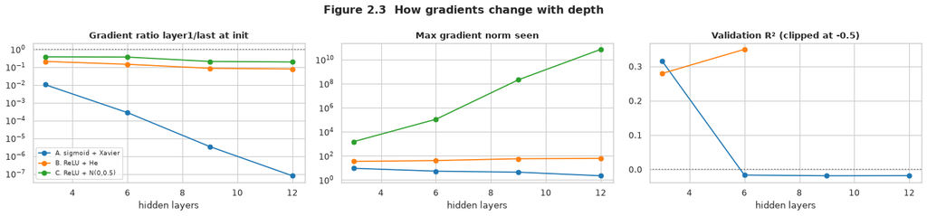

```python
rows = []
for (r, d), res in GR.items():
    h = res['grads'].iloc[0].values[:-1]                      # hidden layers only, at initialisation
    rows.append({'regime': r, 'depth': d, 'grad_L1_init': h[0], 'grad_Llast_init': h[-1], 'ratio_first/last': h[0] / h[-1],
                 'log10_change_per_layer': np.log10(h[0] / h[-1]) / max(1, d - 1),
                 'max_grad_norm': np.nanmax(res['grads'].values), 'diverged': res['diverged'], 'epochs_run': res['epochs'],
                 'val_rmse': res['val']['rmse'], 'val_r2': res['val']['r2']})
GRAD_SUMMARY = pd.DataFrame(rows)
display(GRAD_SUMMARY.style.format({**{c: '{:.2e}' for c in ['grad_L1_init', 'grad_Llast_init', 'ratio_first/last', 'max_grad_norm']},
                                   'log10_change_per_layer': '{:+.3f}', 'val_rmse': '{:.4f}', 'val_r2': '{:.4f}'}))
fig, ax = plt.subplots(1, 3, figsize=(17, 4))
for k, r in enumerate(REGIMES):
    s = GRAD_SUMMARY[GRAD_SUMMARY.regime == r]
    ax[0].semilogy(s.depth, s['ratio_first/last'], '-o', color=PAL[k], label=r)
    ax[1].semilogy(s.depth, s['max_grad_norm'], '-o', color=PAL[k], label=r)
    ax[2].plot(s.depth, s['val_r2'].clip(lower=-0.5), '-o', color=PAL[k], label=r)
ax[0].axhline(1, ls=':', c='grey'); ax[0].set(title='Gradient ratio layer1/last at init', xlabel='hidden layers')
ax[1].set(title='Max gradient norm seen', xlabel='hidden layers')
ax[2].axhline(0, ls=':', c='grey'); ax[2].set(title='Validation R² (clipped at -0.5)', xlabel='hidden layers'); ax[0].legend(fontsize=8)
plt.suptitle('Figure 2.3  How gradients change with depth', fontsize=14, weight='bold'); plt.tight_layout(); plt.show()
```

## 2.4 Fixing the pathologies (12 hidden layers)

Each row applies **one remedy** to a failing 12-layer network: **gradient clipping** (`clipnorm=1`) or **BatchNorm** for the exploding regime C, and **BatchNorm** for the vanishing regime A.

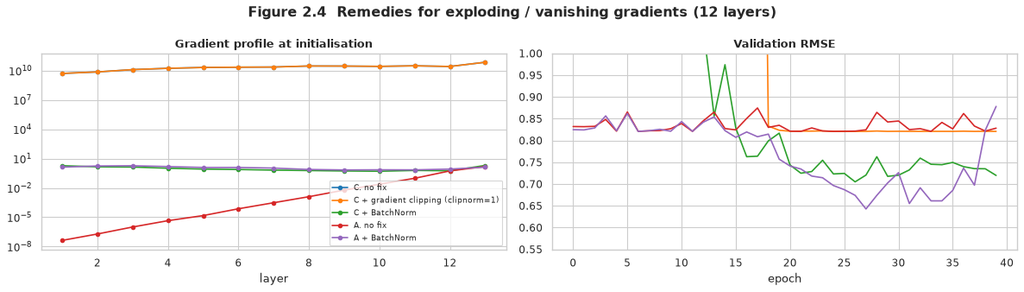

|  | diverged | epochs_run | max_grad_norm | val_rmse | val_r2 |
| --- | --- | --- | --- | --- | --- |
| C. no fix | True | 1 | 72,173,789,184.0000 | NaN | NaN |
| C + gradient clipping (clipnorm=1) | False | 40 | 72,173,789,184.0000 | 0.8208 | -0.0000 |
| C + BatchNorm | False | 40 | 1.9968 | 0.7195 | 0.2316 |
| A. no fix | False | 40 | 2.2352 | 0.8282 | -0.0182 |
| A + BatchNorm | False | 40 | 2.1162 | 0.8759 | -0.1390 |

```python
FIXES = {'C. no fix': ('C. ReLU + N(0,0.5)', None, None),
         'C + gradient clipping (clipnorm=1)': ('C. ReLU + N(0,0.5)', lambda: keras.optimizers.SGD(0.01, momentum=0.9, clipnorm=1.0), None),
         'C + BatchNorm': ('C. ReLU + N(0,0.5)', None, dict(norm='batch')),
         'A. no fix': ('A. sigmoid + Xavier', None, None),
         'A + BatchNorm': ('A. sigmoid + Xavier', None, dict(norm='batch'))}
FIX = {n: (GR[(r, 12)] if (o is None and e is None) else grad_experiment(REGIMES[r], 12, o, e)) for n, (r, o, e) in FIXES.items()}
fig, ax = plt.subplots(1, 2, figsize=(15, 4.3))
for k, (n, res) in enumerate(FIX.items()):
    g = res['grads']; ax[0].semilogy(np.arange(1, g.shape[1] + 1), g.iloc[0], '-o', ms=4, color=PAL[k], label=n)
    ax[1].plot(res['hist']['val_rmse'], color=PAL[k], label=n)
ax[0].set(title='Gradient profile at initialisation', xlabel='layer'); ax[0].legend(fontsize=8)
ax[1].set(title='Validation RMSE', xlabel='epoch', ylim=(0.55, 1.0))
plt.suptitle('Figure 2.4  Remedies for exploding / vanishing gradients (12 layers)', fontsize=14, weight='bold')
plt.tight_layout(); plt.show()
pd.DataFrame({n: {'diverged': r['diverged'], 'epochs_run': r['epochs'], 'max_grad_norm': np.nanmax(r['grads'].values),
                  'val_rmse': r['val']['rmse'], 'val_r2': r['val']['r2']} for n, r in FIX.items()}).T
```

### 2.5 Findings: how gradients change with depth

**Regime A, sigmoid + Xavier (vanishing).**

- **Observation:** at initialisation the first-layer gradient falls from 3.4×10⁻² (3 layers) to 4.3×10⁻⁸ (12 layers), almost six orders of magnitude. Meanwhile the last hidden layer still receives gradients of order 1 (Figure 2.2a, left; Figure 2.3). The ratio between first and last layer falls by about 0.65–1.0 decades *per layer*. The 3-layer network learns (validation R² = 0.32), but the 6-, 9- and 12-layer networks never move off the mean prediction (R² ≈ −0.02; the validation RMSE stays flat at the predict-the-mean level in Figure 2.2c).
- **Reason:** backpropagation multiplies by σ′(z) ≤ 0.25 and by the weight matrix at every layer, so the signal shrinks geometrically with depth. The heatmap (Figure 2.2b) shows the gradients stay this way throughout training, because the early layers cannot learn their way out.
- **Impact:** in deep sigmoid networks the early layers stay effectively frozen at their random initial values. Adding depth then adds cost without adding capacity.

**Regime B, ReLU + He (healthy, but depth still costs stability).**

- **Observation:** the gradient profile is almost flat at every depth (a first/last ratio of 0.08–0.21, decaying only 0.10–0.34 decades per layer). The 3- and 6-layer networks train normally (R² = 0.28 and 0.35). However, the 9- and 12-layer networks **diverged to NaN in the first epoch**: the gradient norm at the output end grows with depth (29 → 52 for the last hidden layer, peaking around 60).
- **Reason:** He initialisation preserves the *variance* of the signal through ReLUs, which solves the vanishing problem. But it does not bound the *size* of a momentum-SGD step. With more layers there are more parameters whose updates add up through the multiplicative chain, so lr = 0.01 with momentum 0.9 becomes too large.
- **Impact:** good initialisation is necessary but not sufficient for deep networks. It should be combined with normalisation, gradient clipping, a smaller or adaptive learning rate, or residual connections.

**Regime C, ReLU + N(0, 0.5²) (exploding).**

- **Observation:** first-layer gradients at initialisation grow from 1.6×10² (3 layers) to 1.5×10⁴, 1.3×10⁷ and 5.2×10⁹ (12 layers), roughly ×10² for every three layers added. Every depth diverged to NaN within the first epoch.
- **Reason:** an initial standard deviation about 2.8× the He value multiplies the forward variance by about 8 per layer, and the backward pass inherits the same growth.

**Remedies (Figure 2.4).**

- *Gradient clipping* stopped the NaNs, so all 40 epochs completed, but the network stayed at R² = 0. Clipping caps the step size; it does not repair the badly scaled forward pass, so the units remain saturated.
- *BatchNorm* fixed the root cause. The maximum gradient norm fell from 7×10¹⁰ to 2.0 and validation R² reached 0.23.
- For the vanishing sigmoid network, BatchNorm lifted the first-layer gradient from about 10⁻⁸ to about 1, a flat profile. It reached a validation RMSE of about 0.64 mid-training, although without early stopping it was unstable by epoch 40. Section 3.4 confirms the rescue on a 9-layer network (R² 0.37 vs 0).

**Summary of how gradients change with depth:** with saturating activations the gradient magnitude falls **exponentially** with depth; with an over-scaled initialisation it **grows exponentially**; with ReLU + He it stays roughly **constant** in shape, but its absolute size, and therefore training stability, still grows with depth.

# Part 3: Advanced Optimization Techniques (15 pts)

### Tasks

1. Compare optimizers: SGD, Adam, RMSprop, AdaGrad.
2. Test weight initializations (Glorot/Xavier, He, etc.).
3. Experiment with activations: ReLU, Leaky ReLU, ELU, Swish.
4. Apply normalization layers.
5. Evaluate learning rate schedules.

|  | val_rmse | val_rmse_std | val_mae | val_r2 | val_qwk | val_within1 | val_good_auc | train_rmse | gap(val-train RMSE) | best_epoch | epochs_run | time |
| --- | --- | --- | --- | --- | --- | --- | --- | --- | --- | --- | --- | --- |
| SGD (0.01) | 0.6451 | 0.0039 | 0.5105 | 0.3823 | 0.5541 | 0.9730 | 0.8794 | 0.5376 | 0.1074 | 30.5000 | 45.5000 | 1.8972 |
| SGD + Nesterov momentum (0.01) | 0.6293 | 0.0163 | 0.5044 | 0.4120 | 0.5387 | 0.9681 | 0.8762 | 0.5613 | 0.0680 | 12.0000 | 27.0000 | 1.7255 |
| Adam (1e-3) | 0.6426 | 0.0007 | 0.5102 | 0.3870 | 0.5325 | 0.9730 | 0.8759 | 0.5325 | 0.1101 | 9.5000 | 24.5000 | 2.0543 |
| RMSprop (1e-3) | 0.6529 | 0.0081 | 0.5193 | 0.3671 | 0.5446 | 0.9730 | 0.8630 | 0.5285 | 0.1244 | 7.0000 | 22.0000 | 1.5689 |
| AdaGrad (0.05) | 0.6257 | 0.0017 | 0.4935 | 0.4189 | 0.5463 | 0.9681 | 0.8711 | 0.5571 | 0.0685 | 13.5000 | 28.5000 | 2.0546 |

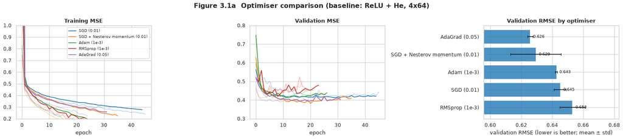

```python
# Shared experiment harness: one call = one configuration trained under every seed in SEEDS
def run_config(name, model_kw=None, opt_fn=lambda: keras.optimizers.Adam(1e-3), seeds=None, epochs=None,
               early_stop=True, patience=15, monitor='val_loss', restore=True, callbacks_fn=None,
               grads=False, X_tr=None, y_tr=None, batch_size=64):
    seeds, epochs = seeds or SEEDS, epochs or E(100)
    X_tr = X_train if X_tr is None else X_tr; y_tr = y_train if y_tr is None else y_tr
    runs = []
    for s in seeds:
        keras.utils.set_random_seed(s)
        model = build_deep_model(N_FEAT, **{'depth': 4, **(model_kw or {})})
        model.compile(optimizer=opt_fn(), loss='mse', metrics=[keras.metrics.RootMeanSquaredError(name='rmse'), 'mae'],
                      steps_per_execution=16)
        lr_cb = LRLogger(); cbs = [keras.callbacks.TerminateOnNaN(), lr_cb]
        if early_stop:
            cbs.append(keras.callbacks.EarlyStopping(monitor=monitor, patience=patience, restore_best_weights=restore))
        gcb = GradientNormCallback(X_tr, y_tr) if (grads and s == seeds[0]) else None
        if gcb: cbs.append(gcb)
        if callbacks_fn: cbs += callbacks_fn()
        t = time.time()
        h = model.fit(make_ds(X_tr, y_tr, batch_size), validation_data=VAL_DS, epochs=epochs, verbose=0, callbacks=cbs)
        hist = pd.DataFrame(h.history); hist['lr'] = lr_cb.lrs[:len(hist)]
        vl = hist['val_loss'].replace([np.inf, -np.inf], np.nan)
        runs.append(dict(seed=s, model=model, hist=hist, grads=gcb.frame() if gcb else None, time=time.time() - t,
                         epochs_run=len(hist), best_epoch=int(vl.idxmin()) + 1 if vl.notna().any() else np.nan,
                         **{f'val_{k}': v for k, v in reg_metrics(y_val, predict(model, X_val)).items()},
                         **{f'train_{k}': v for k, v in reg_metrics(y_tr, predict(model, X_tr)).items()}))
    return dict(name=name, runs=runs)

def summarise(results):
    cols = ['val_rmse', 'val_mae', 'val_r2', 'val_qwk', 'val_within1', 'val_good_auc', 'train_rmse', 'best_epoch', 'epochs_run', 'time']
    out = {}
    for r in results:
        d = pd.DataFrame([{c: run[c] for c in cols} for run in r['runs']])
        out[r['name']] = {**d.mean().to_dict(), 'val_rmse_std': d['val_rmse'].std()}
    t = pd.DataFrame(out).T
    t['gap(val-train RMSE)'] = t['val_rmse'] - t['train_rmse']
    return t[['val_rmse', 'val_rmse_std', 'val_mae', 'val_r2', 'val_qwk', 'val_within1', 'val_good_auc', 'train_rmse',
              'gap(val-train RMSE)', 'best_epoch', 'epochs_run', 'time']]

def curves(results, metric, ax, title, ylim=None):
    for k, r in enumerate(results):
        for j, run in enumerate(r['runs']):
            ax.plot(run['hist'][metric].values, color=PAL[k % 10], alpha=1 if j == 0 else .3, label=r['name'] if j == 0 else None)
    ax.set(title=title, xlabel='epoch');  ax.set_ylim(ylim) if ylim else None

def bars(summary, ax, title):
    s = summary.sort_values('val_rmse', ascending=False)
    ax.barh(s.index, s['val_rmse'], xerr=s['val_rmse_std'].fillna(0), color=PAL[0], alpha=.8, capsize=3)
    lo = np.nanmin(s['val_rmse']) - 0.03; ax.set_xlim(lo, min(np.nanmax(s['val_rmse']) + .03, 1.2))
    for i, v in enumerate(s['val_rmse']): ax.text(min(v, 1.19) + .002, i, f'{v:.3f}', va='center', fontsize=9)
    ax.set(title=title, xlabel='validation RMSE (lower is better; mean ± std)')

BASE = dict(depth=4, units=64, activation='relu', init='he_normal')     # Part-3 baseline architecture

# Loop over optimizers (Section 3.1)
OPTS = {'SGD (0.01)': lambda: keras.optimizers.SGD(0.01),
        'SGD + Nesterov momentum (0.01)': lambda: keras.optimizers.SGD(0.01, momentum=0.9, nesterov=True),
        'Adam (1e-3)': lambda: keras.optimizers.Adam(1e-3),
        'RMSprop (1e-3)': lambda: keras.optimizers.RMSprop(1e-3),
        'AdaGrad (0.05)': lambda: keras.optimizers.Adagrad(0.05)}
OPT_RES = [run_config(n, BASE, f) for n, f in OPTS.items()]
OPT_SUM = summarise(OPT_RES); display(OPT_SUM)
fig, ax = plt.subplots(1, 3, figsize=(19, 4.3))
curves(OPT_RES, 'loss', ax[0], 'Training MSE', (0.2, 1.0)); ax[0].legend(fontsize=8)
curves(OPT_RES, 'val_loss', ax[1], 'Validation MSE', (0.3, 0.8)); bars(OPT_SUM, ax[2], 'Validation RMSE by optimiser')
plt.suptitle('Figure 3.1a  Optimiser comparison (baseline: ReLU + He, 4x64)', fontsize=14, weight='bold'); plt.tight_layout(); plt.show()
```

## 3.1 Optimisers: SGD, SGD + Momentum, Adam, RMSprop and AdaGrad

The cell above trains the baseline network (4 × 64, ReLU + He) with each optimiser at a conventional learning rate (Figure 3.1a). Comparing optimisers at one learning rate each is biased, because every optimiser has its own good range. The sweep below therefore varies the learning rate as the single extra factor (Figure 3.1b).

```
Batch 15: Invalid loss, terminating training
```

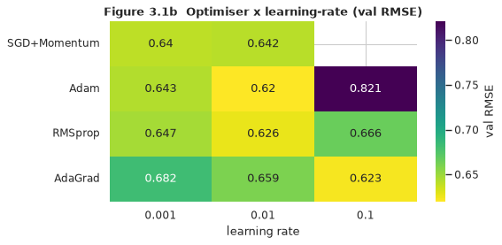

```python
LRS = [1e-3, 1e-2, 1e-1]
OPT_LR = {'SGD+Momentum': lambda lr: keras.optimizers.SGD(lr, momentum=0.9), 'Adam': lambda lr: keras.optimizers.Adam(lr),
          'RMSprop': lambda lr: keras.optimizers.RMSprop(lr), 'AdaGrad': lambda lr: keras.optimizers.Adagrad(lr)}
sens = pd.DataFrame(index=list(OPT_LR), columns=LRS, dtype=float)
for o, f in OPT_LR.items():
    for lr in LRS:
        sens.loc[o, lr] = run_config(f'{o}@{lr}', BASE, (lambda f=f, lr=lr: f(lr)), seeds=[SEED], epochs=E(60), patience=10)['runs'][0]['val_rmse']
plt.figure(figsize=(7, 3.3)); sns.heatmap(sens.clip(upper=1.2), annot=sens.round(3), fmt='', cmap='viridis_r', cbar_kws={'label': 'val RMSE'})
plt.title('Figure 3.1b  Optimiser x learning-rate (val RMSE)'); plt.xlabel('learning rate'); plt.show()
```

**Optimiser findings (Figures 3.1a–b).**

- **Observation:** at the default learning rates, **AdaGrad (0.6257 ± 0.002)** and **SGD + Nesterov momentum (0.6293 ± 0.016)** reach the lowest validation RMSE, ahead of Adam (0.6426) and RMSprop (0.6529). Adam and RMSprop reach their best epoch fastest (epochs 7–10) but also overfit fastest: their train–validation gap is 0.11–0.12 RMSE, against about 0.07 for AdaGrad and SGD + Nesterov. Plain SGD converges slowly (best epoch about 31).
- The learning-rate sweep changes the ranking. **Adam at lr = 0.01 (0.620)** and **AdaGrad at lr = 0.1 (0.623)** are the best cells overall, while Adam at 0.1 collapses to the mean (0.821) and SGD + Momentum at 0.1 diverges (blank cell).
- **Reason:** AdaGrad's accumulated squared gradients shrink its step size over time, a built-in decay that suits a small, quickly learned dataset. Adam's bias-corrected moments allow larger steps, which help at moderate learning rates but overshoot at 0.1.
- **Impact:** optimiser rankings depend on the learning rate. Each optimiser must be tuned before comparing them, and the differences at their best settings (about 0.005 RMSE) are smaller than the seed-to-seed spread.

## 3.2 Weight-initialisation strategies

**One factor:** the initialiser. Fixed: 6 hidden layers, ReLU, SGD + momentum (Adam would partly mask a poor initial scale). Compared: **Xavier/Glorot** uniform and normal (Var = 2/(fan_in + fan_out)), **He** normal and uniform (Var = 2/fan_in, derived for ReLU), **LeCun** normal (Var = 1/fan_in), a too-small N(0, 0.01²), a too-large N(0, 1), and **zeros**. Before any training, the **forward signal** is also measured: the standard deviation of each layer's activations.

```
Batch 15: Invalid loss, terminating training
```

```
Batch 15: Invalid loss, terminating training
```

|  | val_rmse | val_rmse_std | val_mae | val_r2 | val_qwk | val_within1 | val_good_auc | train_rmse | gap(val-train RMSE) | best_epoch | epochs_run | time |
| --- | --- | --- | --- | --- | --- | --- | --- | --- | --- | --- | --- | --- |
| Xavier uniform | 0.6305 | 0.0118 | 0.4944 | 0.4098 | 0.5349 | 0.9632 | 0.8703 | 0.5833 | 0.0472 | 8.5000 | 23.5000 | 1.9907 |
| Xavier normal | 0.6270 | 0.0183 | 0.4911 | 0.4162 | 0.5449 | 0.9706 | 0.8768 | 0.5618 | 0.0652 | 10.5000 | 25.5000 | 2.0602 |
| He normal | 0.6315 | 0.0043 | 0.4984 | 0.4080 | 0.5257 | 0.9706 | 0.8783 | 0.5219 | 0.1096 | 21.0000 | 36.0000 | 2.7114 |
| He uniform | 0.6448 | 0.0136 | 0.5033 | 0.3827 | 0.5402 | 0.9559 | 0.8591 | 0.5257 | 0.1191 | 11.5000 | 26.5000 | 2.1098 |
| LeCun normal | 0.6265 | 0.0209 | 0.4949 | 0.4171 | 0.5537 | 0.9706 | 0.8745 | 0.5629 | 0.0635 | 9.0000 | 24.0000 | 2.0160 |
| Small N(0,0.01) | 0.8208 | 0.0000 | 0.6932 | -0.0000 | 0.0000 | 0.9412 | 0.5000 | 0.8237 | -0.0030 | 17.5000 | 32.5000 | 2.2265 |
| Large N(0,1) | NaN | NaN | NaN | NaN | NaN | NaN | NaN | NaN | NaN | NaN | 1.0000 | 1.3153 |
| Zeros | 0.8208 | 0.0000 | 0.6932 | -0.0000 | 0.0000 | 0.9412 | 0.5000 | 0.8237 | -0.0030 | 17.5000 | 32.5000 | 2.8000 |

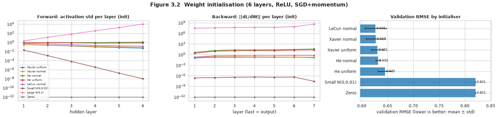

```python
INITS = {'Xavier uniform': 'glorot_uniform', 'Xavier normal': 'glorot_normal', 'He normal': 'he_normal', 'He uniform': 'he_uniform',
         'LeCun normal': 'lecun_normal', 'Small N(0,0.01)': lambda: keras.initializers.RandomNormal(stddev=0.01),
         'Large N(0,1)': lambda: keras.initializers.RandomNormal(stddev=1.0), 'Zeros': 'zeros'}
SGDM = lambda: keras.optimizers.SGD(0.01, momentum=0.9)

def act_outputs(model, X):
    outs = keras.Model(model.inputs, [l.output for l in model.layers if l.name.startswith('act_')])(X, training=False)
    return [o.numpy() for o in outs]

act_std = {}
for n, i in INITS.items():
    keras.utils.set_random_seed(SEED); act_std[n] = [float(np.std(a)) for a in act_outputs(build_deep_model(N_FEAT, 6, init=i), X_train)]
INIT_RES = [run_config(n, dict(depth=6, init=i), SGDM, grads=True) for n, i in INITS.items()]
INIT_SUM = summarise(INIT_RES); display(INIT_SUM)
fig, ax = plt.subplots(1, 3, figsize=(19, 4.5))
for k, r in enumerate(INIT_RES):
    ax[0].semilogy(range(1, 7), np.maximum(act_std[r['name']], 1e-12), '-o', ms=4, color=PAL[k], label=r['name'])
    g = r['runs'][0]['grads']; ax[1].semilogy(range(1, g.shape[1] + 1), np.maximum(g.iloc[0], 1e-12), '-o', ms=4, color=PAL[k])
ax[0].set(title='Forward: activation std per layer (init)', xlabel='hidden layer'); ax[0].legend(fontsize=7)
ax[1].set(title='Backward: ||dL/dW|| per layer (init)', xlabel='layer (last = output)'); bars(INIT_SUM, ax[2], 'Validation RMSE by initialiser')
plt.suptitle('Figure 3.2  Weight initialisation (6 layers, ReLU, SGD+momentum)', fontsize=14, weight='bold'); plt.tight_layout(); plt.show()
```

**Initialisation findings (Figure 3.2).**

- **Observation:** all variance-scaled schemes cluster together (val RMSE 0.627–0.645): LeCun normal 0.6265, Xavier normal 0.6270, Xavier uniform 0.6305, He normal 0.6315, He uniform 0.6448. The naive schemes fail completely. **Zeros** and **small N(0, 0.01)** stay at the mean prediction (R² = 0; QWK = 0). **Large N(0, 1)** diverges to NaN in the first epoch.
- **Reason:** with zeros, every unit in a layer computes the same output and receives the same gradient, so this symmetry is never broken. With std 0.01 the forward signal shrinks by about 10× per layer (Figure 3.2, left), so both activations and gradients vanish. With std 1 the signal grows instead, causing explosion. The Glorot, He and LeCun formulas set Var(W) ∝ 1/fan so that activation variance stays roughly constant across layers (flat lines in the forward-signal panel).
- He normal had the **lowest variance across seeds** (std 0.004) and is the theoretically matched choice for the ReLU family, so it is kept for later experiments.
- **Impact:** at depth 6 the choice among principled initialisers matters far less than avoiding an unprincipled one. A bad initialisation is a failure mode, not a small accuracy cost.

## 3.3 Activation functions: ReLU, Leaky ReLU, ELU and Swish

**One factor:** the activation. Fixed: 6 × 64, He initialisation, Adam 1e-3. Tanh with Xavier is included as a classic reference. After training, **dead units** are counted: hidden units whose output is ≤ 0 for every training example, so they pass no gradient (the "dying ReLU" problem).

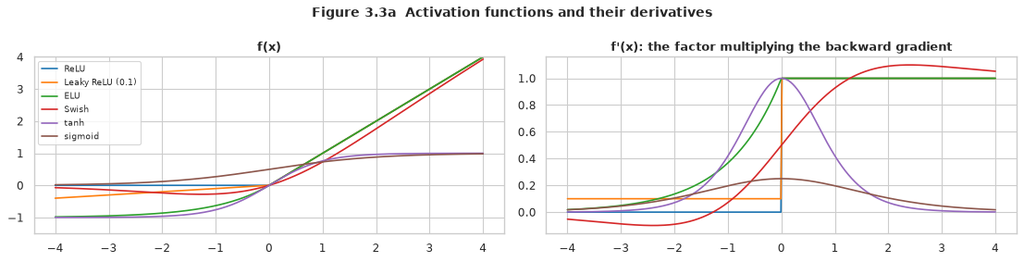

|  | val_rmse | val_rmse_std | val_mae | val_r2 | val_qwk | val_within1 | val_good_auc | train_rmse | gap(val-train RMSE) | best_epoch | epochs_run | time | dead_units_% |
| --- | --- | --- | --- | --- | --- | --- | --- | --- | --- | --- | --- | --- | --- |
| ReLU | 0.6468 | 0.0130 | 0.5135 | 0.3789 | 0.4996 | 0.9681 | 0.8894 | 0.5638 | 0.0830 | 5.5000 | 20.5000 | 2.5978 | 1.4323 |
| Leaky ReLU (0.1) | 0.6458 | 0.0127 | 0.5036 | 0.3808 | 0.5695 | 0.9755 | 0.8839 | 0.5143 | 0.1315 | 8.5000 | 23.5000 | 2.6577 | 0.5208 |
| ELU | 0.6995 | 0.0031 | 0.5430 | 0.2736 | 0.5004 | 0.9534 | 0.8364 | 0.4403 | 0.2592 | 16.5000 | 31.5000 | 2.9107 | 0.0000 |
| Swish | 0.6348 | 0.0017 | 0.4974 | 0.4018 | 0.5172 | 0.9657 | 0.8756 | 0.6094 | 0.0254 | 3.5000 | 18.5000 | 3.0043 | 0.0000 |
| tanh (+Xavier) | 0.6284 | 0.0145 | 0.4886 | 0.4136 | 0.5525 | 0.9706 | 0.8723 | 0.5578 | 0.0706 | 23.0000 | 38.0000 | 3.7867 | 0.0000 |

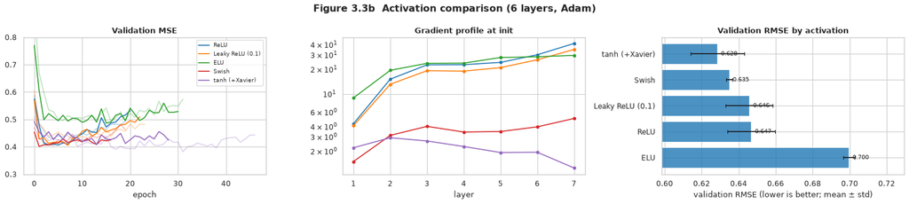

```python
xs = np.linspace(-4, 4, 400); sg = 1 / (1 + np.exp(-xs))
FNS = {'ReLU': (np.maximum(0, xs), (xs > 0) * 1.), 'Leaky ReLU (0.1)': (np.where(xs > 0, xs, .1 * xs), np.where(xs > 0, 1, .1)),
       'ELU': (np.where(xs > 0, xs, np.exp(xs) - 1), np.where(xs > 0, 1, np.exp(xs))), 'Swish': (xs * sg, sg * (1 + xs * (1 - sg))),
       'tanh': (np.tanh(xs), 1 - np.tanh(xs) ** 2), 'sigmoid': (sg, sg * (1 - sg))}
fig, ax = plt.subplots(1, 2, figsize=(14, 3.6))
for k, (n, (f, d)) in enumerate(FNS.items()):
    ax[0].plot(xs, f, color=PAL[k], label=n); ax[1].plot(xs, d, color=PAL[k], label=n)
ax[0].set(title='f(x)', ylim=(-1.5, 4)); ax[1].set(title="f'(x): the factor multiplying the backward gradient"); ax[0].legend(fontsize=8)
plt.suptitle('Figure 3.3a  Activation functions and their derivatives', fontsize=13, weight='bold'); plt.tight_layout(); plt.show()

ACTS = {'ReLU': ('relu', 'he_normal'), 'Leaky ReLU (0.1)': ('leaky_relu', 'he_normal'), 'ELU': ('elu', 'he_normal'),
        'Swish': ('swish', 'he_normal'), 'tanh (+Xavier)': ('tanh', 'glorot_uniform')}
ACT_RES = [run_config(n, dict(depth=6, activation=a, init=i), grads=True) for n, (a, i) in ACTS.items()]
ACT_SUM = summarise(ACT_RES)
dead = {r['name']: 100 * np.mean([np.mean(np.concatenate([o.max(0) <= 1e-8 for o in act_outputs(run['model'], X_train)]))
                                   for run in r['runs']]) for r in ACT_RES}
ACT_SUM['dead_units_%'] = pd.Series(dead); display(ACT_SUM)
fig, ax = plt.subplots(1, 3, figsize=(19, 4.3))
curves(ACT_RES, 'val_loss', ax[0], 'Validation MSE', (0.3, 0.8)); ax[0].legend(fontsize=8)
for k, r in enumerate(ACT_RES):
    g = r['runs'][0]['grads']; ax[1].semilogy(range(1, g.shape[1] + 1), g.iloc[0], '-o', ms=4, color=PAL[k], label=r['name'])
ax[1].set(title='Gradient profile at init', xlabel='layer'); bars(ACT_SUM, ax[2], 'Validation RMSE by activation')
plt.suptitle('Figure 3.3b  Activation comparison (6 layers, Adam)', fontsize=14, weight='bold'); plt.tight_layout(); plt.show()
```

**Activation findings (Figures 3.3a–b).**

- **Observation:** **tanh + Xavier (0.6284)** and **Swish (0.6348 ± 0.002)** lead, followed by Leaky ReLU (0.6458), ReLU (0.6468) and ELU (0.6995). Plain ReLU left **1.4%** of hidden units dead (they output zero for every training wine). Leaky ReLU cut this to 0.5%, and ELU, Swish and tanh had none. Swish also had the **smallest generalisation gap** (0.025), while ELU overfit most (gap 0.26, best epoch 16.5).
- **Reason:** Swish (x·σ(x)) is smooth and non-monotonic, and lets small negative values through, so gradients never become exactly zero and units cannot die. ReLU's zero gradient for negative inputs is what produces dead units. The smooth bounded activations (tanh, Swish) also act as a mild regulariser on this small, noisy target.
- **Impact:** Swish is the best of the four ReLU-family activations the rubric names. Its low seed variance makes it a dependable default, so it is carried into Section 3.6 and into the final-candidate pool.

## 3.4 Batch normalisation and layer normalisation

**One factor:** the normalisation layer (none, BatchNorm or LayerNorm), tested in two settings:

- **(a) Rescue:** a 9-layer **sigmoid** network with SGD + momentum, which suffers vanishing gradients in Part 2.
- **(b) Modern:** a 6-layer ReLU network with Adam, where gradients are already healthy.

BatchNorm normalises each unit across the **mini-batch** and keeps running statistics for inference. LayerNorm normalises across the **features of each sample**, so it behaves the same at training and inference time and does not depend on batch size.

|  | val_rmse | val_rmse_std | val_mae | val_r2 | val_qwk | val_within1 | val_good_auc | train_rmse | gap(val-train RMSE) | best_epoch | epochs_run | time |
| --- | --- | --- | --- | --- | --- | --- | --- | --- | --- | --- | --- | --- |
| sigmoid-9 \| no norm | 0.8208 | 0.0000 | 0.6933 | -0.0000 | 0.0000 | 0.9412 | 0.4410 | 0.8237 | -0.0030 | 13.0000 | 28.0000 | 2.5678 |
| sigmoid-9 \| BatchNorm | 0.6495 | 0.0091 | 0.5020 | 0.3737 | 0.5082 | 0.9657 | 0.8610 | 0.5666 | 0.0829 | 33.5000 | 48.5000 | 6.5870 |
| sigmoid-9 \| LayerNorm | 0.8208 | 0.0000 | 0.6939 | -0.0002 | 0.0000 | 0.9412 | 0.5645 | 0.8237 | -0.0029 | 8.5000 | 23.5000 | 5.6842 |
| ReLU-6 \| no norm | 0.6468 | 0.0130 | 0.5135 | 0.3789 | 0.4996 | 0.9681 | 0.8894 | 0.5638 | 0.0830 | 5.5000 | 20.5000 | 3.4781 |
| ReLU-6 \| BatchNorm | 0.6746 | 0.0374 | 0.5339 | 0.3234 | 0.5183 | 0.9779 | 0.8593 | 0.5376 | 0.1370 | 12.0000 | 27.0000 | 4.8809 |
| ReLU-6 \| LayerNorm | 0.6332 | 0.0041 | 0.4992 | 0.4047 | 0.5701 | 0.9779 | 0.8912 | 0.5523 | 0.0810 | 7.0000 | 22.0000 | 5.8339 |

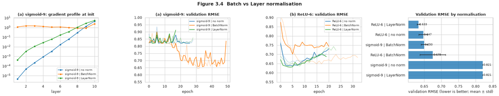

```python
NORMS = [('no norm', None), ('BatchNorm', 'batch'), ('LayerNorm', 'layer')]
NORM_A = [run_config(f'sigmoid-9 | {n}', dict(depth=9, activation='sigmoid', init='glorot_uniform', norm=v), SGDM, grads=True) for n, v in NORMS]
NORM_B = [run_config(f'ReLU-6 | {n}', dict(depth=6, norm=v), grads=True) for n, v in NORMS]
NORM_SUM = summarise(NORM_A + NORM_B); display(NORM_SUM)
fig, ax = plt.subplots(1, 4, figsize=(22, 4.3))
for k, r in enumerate(NORM_A):
    g = r['runs'][0]['grads']; ax[0].semilogy(range(1, g.shape[1] + 1), g.iloc[0], '-o', ms=4, color=PAL[k], label=r['name'])
curves(NORM_A, 'val_rmse', ax[1], '(a) sigmoid-9: validation RMSE', (0.55, 1.0)); curves(NORM_B, 'val_rmse', ax[2], '(b) ReLU-6: validation RMSE', (0.55, 0.9))
ax[0].set(title='(a) sigmoid-9: gradient profile at init', xlabel='layer'); ax[0].legend(fontsize=8); ax[1].legend(fontsize=8); ax[2].legend(fontsize=8)
bars(NORM_SUM, ax[3], 'Validation RMSE by normalisation')
plt.suptitle('Figure 3.4  Batch vs Layer normalisation', fontsize=14, weight='bold'); plt.tight_layout(); plt.show()
```

**Normalisation findings (Figure 3.4).**

- **(a) Rescue setting.** The 9-layer sigmoid network without normalisation, and with LayerNorm, stays at the mean prediction (val RMSE 0.8208, R² ≈ 0). **BatchNorm rescues it: val RMSE 0.6495, R² 0.37.** Its gradient profile at initialisation becomes flat instead of falling by orders of magnitude.
- **(b) Modern setting.** With ReLU and Adam, **LayerNorm** gives the best and most stable result (0.6332 ± 0.004), while BatchNorm is *worse* than no normalisation (0.6746 ± 0.037, gap 0.137).
- **Reason:** BatchNorm re-centres each unit's pre-activation across the batch, which keeps sigmoid inputs in the region where σ′ is largest and so restores gradient flow. LayerNorm normalises across the units of one sample. For a sigmoid, that does not stop units from all saturating together, so it cannot fix vanishing. Once gradients are healthy, BatchNorm's batch-to-batch noise with batches of 64 (and the train/inference mismatch) adds variance, whereas LayerNorm behaves the same at training and inference time.
- **Impact:** use BatchNorm to make a deep, poorly conditioned network trainable. In small-batch tabular settings LayerNorm is the safer stabiliser. (Section 4.6 shows LayerNorm's single-split advantage does not hold up under cross-validation.)

## 3.5 Learning-rate scheduling

**One factor:** the schedule. Fixed: the baseline network, SGD + momentum with a peak learning rate of 0.01 (the SGD + momentum value from 3.1), and 60 epochs **without** early stopping (early stopping would cut decaying schedules short).

| Schedule | Definition |
| --- | --- |
| Constant | lr = 0.01 throughout |
| Step decay | halve every 15 epochs (`LearningRateScheduler`) |
| Exponential decay | ×0.95 per epoch, applied per step (`ExponentialDecay`) |
| Cosine + warm-up | 5-epoch linear warm-up, then cosine decay to 0 (`CosineDecay(warmup_target=...)`) |
| ReduceLROnPlateau | halve when validation loss stalls for 4 epochs |

|  | val_rmse | val_rmse_std | best_val_rmse_any_epoch | val_rmse_last5_std | val_r2 | val_qwk | train_rmse | gap(val-train RMSE) |
| --- | --- | --- | --- | --- | --- | --- | --- | --- |
| Constant | 0.7535 | 0.0000 | 0.6361 | 0.0061 | 0.1573 | 0.4955 | 0.2090 | 0.5445 |
| Step decay (x0.5/15 ep) | 0.6925 | 0.0264 | 0.6365 | 0.0012 | 0.2876 | 0.5199 | 0.3437 | 0.3488 |
| Exponential decay | 0.6662 | 0.0117 | 0.6366 | 0.0007 | 0.3410 | 0.5362 | 0.4205 | 0.2458 |
| Cosine + warm-up | 0.7233 | 0.0097 | 0.6440 | 0.0001 | 0.2234 | 0.5367 | 0.2030 | 0.5203 |
| ReduceLROnPlateau | 0.6556 | 0.0152 | 0.6358 | 0.0000 | 0.3618 | 0.5557 | 0.4590 | 0.1966 |

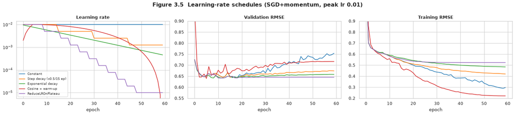

```python
LR0, EP_S, STEPS = 0.01, E(60), math.ceil(len(X_train) / 64)
SCHED = {
    'Constant': dict(opt_fn=lambda: keras.optimizers.SGD(LR0, momentum=0.9)),
    'Step decay (x0.5/15 ep)': dict(opt_fn=lambda: keras.optimizers.SGD(LR0, momentum=0.9),
        callbacks_fn=lambda: [keras.callbacks.LearningRateScheduler(lambda ep, lr: LR0 * 0.5 ** (ep // 15))]),
    'Exponential decay': dict(opt_fn=lambda: keras.optimizers.SGD(keras.optimizers.schedules.ExponentialDecay(LR0, STEPS, 0.95), momentum=0.9)),
    'Cosine + warm-up': dict(opt_fn=lambda: keras.optimizers.SGD(keras.optimizers.schedules.CosineDecay(
        0.0, STEPS * (EP_S - 5), warmup_target=LR0, warmup_steps=STEPS * 5), momentum=0.9)),
    'ReduceLROnPlateau': dict(opt_fn=lambda: keras.optimizers.SGD(LR0, momentum=0.9),
        callbacks_fn=lambda: [keras.callbacks.ReduceLROnPlateau('val_loss', factor=0.5, patience=4, min_lr=1e-5)])}
SCHED_RES = [run_config(n, BASE, epochs=EP_S, early_stop=False, **kw) for n, kw in SCHED.items()]
SCHED_SUM = summarise(SCHED_RES)
SCHED_SUM['best_val_rmse_any_epoch'] = [np.mean([run['hist']['val_rmse'].min() for run in r['runs']]) for r in SCHED_RES]
SCHED_SUM['val_rmse_last5_std'] = [np.mean([run['hist']['val_rmse'].iloc[-5:].std() for run in r['runs']]) for r in SCHED_RES]
display(SCHED_SUM[['val_rmse', 'val_rmse_std', 'best_val_rmse_any_epoch', 'val_rmse_last5_std', 'val_r2', 'val_qwk', 'train_rmse', 'gap(val-train RMSE)']])
fig, ax = plt.subplots(1, 3, figsize=(19, 4.3))
for k, r in enumerate(SCHED_RES):
    h = r['runs'][0]['hist']; ax[0].plot(h['lr'], color=PAL[k], label=r['name'])
    ax[1].plot(h['val_rmse'], color=PAL[k]); ax[2].plot(h['rmse'], color=PAL[k])
ax[0].set(title='Learning rate', xlabel='epoch', yscale='log'); ax[0].legend(fontsize=8)
ax[1].set(title='Validation RMSE', xlabel='epoch', ylim=(0.55, 0.9)); ax[2].set(title='Training RMSE', xlabel='epoch', ylim=(0.2, 0.9))
plt.suptitle('Figure 3.5  Learning-rate schedules (SGD+momentum, peak lr 0.01)', fontsize=14, weight='bold'); plt.tight_layout(); plt.show()
```

**Learning-rate schedule findings (Figure 3.5).**

- **Observation:** all schedules reach a similar *best* validation RMSE at some epoch (0.636–0.644), because the first few epochs are almost identical. They differ sharply in what happens **afterwards**. With a **constant** rate the network keeps fitting the training set (train RMSE 0.21) and validation RMSE drifts up to **0.754** (gap 0.54). **ReduceLROnPlateau** ends best (**0.656**, gap 0.20, perfectly stable final epochs), followed by exponential decay (0.666) and step decay (0.693). Cosine with warm-up ends at 0.723: it keeps the learning rate high for most of the run, so it overfits before it anneals.
- **Reason:** a decaying learning rate shrinks the step size once the loss surface has been explored, so the optimiser settles rather than continuing to memorise noise. ReduceLROnPlateau does this adaptively, at the moment validation loss stops improving.
- **Impact:** for fixed-budget training, a feedback-driven schedule gives the best and most stable end-of-training model. It is also a safety net if early stopping is misconfigured.

## 3.6 Combining the evidence: tuned configuration vs baseline

The individually best choices from Sections 3.1–3.5 are combined. Because this changes several factors at once, it is presented as a **confirmation** run against the Part 3 baseline, not as an attribution experiment.

|  | val_rmse | val_rmse_std | val_mae | val_r2 | val_qwk | val_within1 | val_good_auc | train_rmse | gap(val-train RMSE) | best_epoch | epochs_run | time |
| --- | --- | --- | --- | --- | --- | --- | --- | --- | --- | --- | --- | --- |
| Baseline: ReLU + He + Adam(1e-3) | 0.6426 | 0.0007 | 0.5102 | 0.3870 | 0.5325 | 0.9730 | 0.8759 | 0.5325 | 0.1101 | 9.5000 | 24.5000 | 3.3550 |
| Tuned: Swish + He + LayerNorm, SGD-Nesterov + ReduceLROnPlateau | 0.6261 | 0.0069 | 0.4918 | 0.4180 | 0.5744 | 0.9755 | 0.8744 | 0.5542 | 0.0719 | 15.5000 | 35.5000 | 4.0862 |

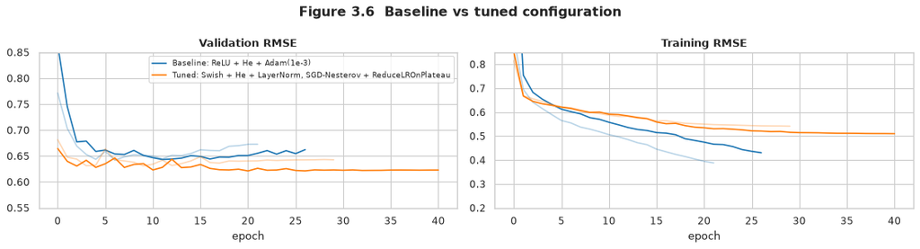

```python
# Evidence used: 3.1 SGD+Nesterov among the best optimisers | 3.2 He init (matched to the ReLU family, stable across seeds)
#                3.3 Swish best ReLU-family activation, no dead units | 3.4 LayerNorm best in the ReLU-6 setting
#                3.5 ReduceLROnPlateau best final val RMSE and smallest gap
TUNED = dict(depth=4, units=64, activation='swish', init='he_normal', norm='layer')
TUNED_OPT = lambda: keras.optimizers.SGD(0.01, momentum=0.9, nesterov=True)
PLATEAU = lambda: [keras.callbacks.ReduceLROnPlateau('val_loss', factor=0.5, patience=4, min_lr=1e-5)]
COMBO = [run_config('Baseline: ReLU + He + Adam(1e-3)', BASE),
         run_config('Tuned: Swish + He + LayerNorm, SGD-Nesterov + ReduceLROnPlateau', TUNED, TUNED_OPT, callbacks_fn=PLATEAU, patience=20)]
COMBO_SUM = summarise(COMBO); display(COMBO_SUM)
fig, ax = plt.subplots(1, 2, figsize=(14, 3.8))
curves(COMBO, 'val_rmse', ax[0], 'Validation RMSE', (0.55, 0.85)); curves(COMBO, 'rmse', ax[1], 'Training RMSE', (0.2, 0.85)); ax[0].legend(fontsize=8)
plt.suptitle('Figure 3.6  Baseline vs tuned configuration', fontsize=14, weight='bold'); plt.tight_layout(); plt.show()
```

# Part 4: Regularization & Generalization (6 pts)

### Tasks

1. Apply L1, L2, and Elastic Net.
2. Implement dropout at different layers.
3. Use early stopping with patience.
4. Plot learning curves; analyze bias-variance.

|  | val_rmse | val_mae | val_r2 | val_qwk | train_rmse | gap(val-train RMSE) | min_val_rmse | w_l2 | w_sparsity_pct |
| --- | --- | --- | --- | --- | --- | --- | --- | --- | --- |
| No regularisation | 0.7019 | 0.5214 | 0.2679 | 0.5638 | 0.1232 | 0.5788 | 0.6339 | 33.2510 | 0.5555 |
| L1 (1e-4) | 0.7043 | 0.5381 | 0.2635 | 0.5664 | 0.1148 | 0.5895 | 0.6335 | 27.2933 | 20.2065 |
| L2 (1e-3) | 0.7211 | 0.5449 | 0.2278 | 0.5134 | 0.1780 | 0.5432 | 0.6333 | 21.1644 | 4.4490 |
| Elastic net (L1 5e-5 + L2 5e-4) | 0.7093 | 0.5451 | 0.2532 | 0.5457 | 0.1745 | 0.5348 | 0.6336 | 23.5593 | 12.6168 |

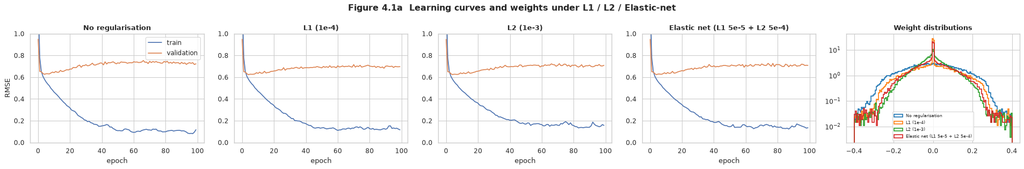

```python
# Regularization examples: L1, L2 and Elastic Net on a deliberately over-parameterised network
# (4 x 128, Adam 1e-3, 100 epochs, no early stopping) so that overfitting -- and its cure -- is visible.
OVERFIT = dict(depth=4, units=128)
EP_R = E(100)

def weight_stats(model):
    w = np.concatenate([l.kernel.numpy().ravel() for l in model.layers if isinstance(l, layers.Dense)])
    return dict(w_l2=float(np.linalg.norm(w)), w_sparsity_pct=float(100 * np.mean(np.abs(w) < 1e-3)))

def run_reg(name, seeds=None, **kw):
    r = run_config(name, {**OVERFIT, **kw.pop('model_kw', {})}, epochs=kw.pop('epochs', EP_R),
                   early_stop=kw.pop('early_stop', False), seeds=seeds or [SEED], **kw)
    for run in r['runs']:
        run.update(weight_stats(run['model'])); run['min_val_rmse'] = run['hist']['val_rmse'].min()
    return r

def reg_table(results):
    t = summarise(results)
    extra = pd.DataFrame({r['name']: {k: np.mean([x[k] for x in r['runs']]) for k in ('min_val_rmse', 'w_l2', 'w_sparsity_pct')} for r in results}).T
    return t[['val_rmse', 'val_mae', 'val_r2', 'val_qwk', 'train_rmse', 'gap(val-train RMSE)']].join(extra)

REG_RES = [run_reg('No regularisation', seeds=SEEDS),
           run_reg('L1 (1e-4)', seeds=SEEDS, model_kw=dict(reg=('l1', 1e-4))),
           run_reg('L2 (1e-3)', seeds=SEEDS, model_kw=dict(reg=('l2', 1e-3))),
           run_reg('Elastic net (L1 5e-5 + L2 5e-4)', seeds=SEEDS, model_kw=dict(reg=('l1l2', 5e-5, 5e-4)))]
REG_SUM = reg_table(REG_RES); display(REG_SUM)
fig, axes = plt.subplots(1, 5, figsize=(24, 4))
for ax, r in zip(axes, REG_RES):
    h = r['runs'][0]['hist']; ax.plot(h['rmse'], label='train'); ax.plot(h['val_rmse'], label='validation')
    ax.set(title=r['name'], xlabel='epoch', ylim=(0, 1.0))
axes[0].legend(); axes[0].set_ylabel('RMSE')
for k, r in enumerate(REG_RES):
    w = np.concatenate([l.kernel.numpy().ravel() for l in r['runs'][0]['model'].layers if isinstance(l, layers.Dense)])
    axes[4].hist(w, bins=150, range=(-.4, .4), histtype='step', lw=1.5, color=PAL[k], density=True, label=r['name'])
axes[4].set(title='Weight distributions', yscale='log'); axes[4].legend(fontsize=7)
plt.suptitle('Figure 4.1a  Learning curves and weights under L1 / L2 / Elastic-net', fontsize=14, weight='bold'); plt.tight_layout(); plt.show()

# Dropout and early stopping -> sections 4.2 and 4.3 below
```

### 4.1b Validation curve: L2 strength (λ)

A validation curve sweeps one complexity control. A λ that is too small leaves **high variance** (a large train–validation gap); a λ that is too large causes **high bias** (both errors rise).

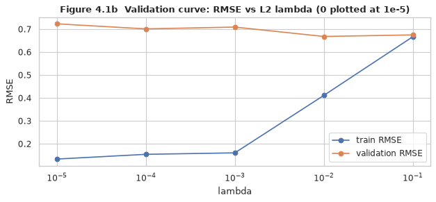

|  | val_rmse | val_mae | val_r2 | val_qwk | train_rmse | gap(val-train RMSE) | min_val_rmse | w_l2 | w_sparsity_pct |
| --- | --- | --- | --- | --- | --- | --- | --- | --- | --- |
| L2=0 | 0.7230 | 0.5319 | 0.2241 | 0.5809 | 0.1335 | 0.5894 | 0.6263 | 33.3723 | 0.5261 |
| L2=0.0001 | 0.7010 | 0.5412 | 0.2705 | 0.5585 | 0.1541 | 0.5469 | 0.6248 | 30.3168 | 1.3898 |
| L2=0.001 | 0.7089 | 0.5322 | 0.2540 | 0.5491 | 0.1605 | 0.5484 | 0.6241 | 21.5524 | 3.6255 |
| L2=0.01 | 0.6679 | 0.5203 | 0.3379 | 0.5410 | 0.4110 | 0.2569 | 0.6124 | 6.7622 | 32.8419 |
| L2=0.1 | 0.6748 | 0.5152 | 0.3241 | 0.4016 | 0.6667 | 0.0081 | 0.6266 | 3.0416 | 69.8335 |

```python
L2_GRID = [0, 1e-4, 1e-3, 1e-2, 1e-1]
VC = reg_table([run_reg(f'L2={l:g}', model_kw=dict(reg=('l2', l) if l else None)) for l in L2_GRID])
xs_ = [1e-5] + L2_GRID[1:]
fig, ax = plt.subplots(figsize=(8, 3.8))
ax.semilogx(xs_, VC['train_rmse'], '-o', label='train RMSE'); ax.semilogx(xs_, VC['val_rmse'], '-o', label='validation RMSE')
ax.set(title='Figure 4.1b  Validation curve: RMSE vs L2 lambda (0 plotted at 1e-5)', xlabel='lambda', ylabel='RMSE'); ax.legend()
plt.tight_layout(); plt.show(); VC
```

## 4.2 Dropout: rates and positions

**Rates** (one factor): 0, 0.1, 0.3 and 0.5 after every hidden layer. **Positions** (one factor, rate fixed at 0.3): early half only, late half only, and all hidden layers. A further run uses 0.1 dropout on the **inputs only**, which acts as feature noise.

|  | val_rmse | val_mae | val_r2 | val_qwk | train_rmse | gap(val-train RMSE) | min_val_rmse | w_l2 | w_sparsity_pct |
| --- | --- | --- | --- | --- | --- | --- | --- | --- | --- |
| rate 0.0 (all hidden) | 0.7230 | 0.5319 | 0.2241 | 0.5809 | 0.1335 | 0.5894 | 0.6263 | 33.3723 | 0.5261 |
| rate 0.1 (all hidden) | 0.6293 | 0.4953 | 0.4122 | 0.5974 | 0.3307 | 0.2985 | 0.6190 | 32.5858 | 0.6144 |
| rate 0.3 (all hidden) | 0.6754 | 0.5610 | 0.3229 | 0.3580 | 0.6523 | 0.0231 | 0.6739 | 31.5623 | 0.5751 |
| rate 0.5 (all hidden) | 0.7426 | 0.6249 | 0.1814 | 0.3851 | 0.7367 | 0.0059 | 0.7426 | 31.2872 | 0.5928 |
| early half (0.3) | 0.6437 | 0.5251 | 0.3850 | 0.5182 | 0.5373 | 0.1064 | 0.6266 | 31.9281 | 0.6399 |
| late half (0.3) | 0.6605 | 0.5200 | 0.3523 | 0.5753 | 0.2179 | 0.4427 | 0.6170 | 32.9067 | 0.6026 |
| inputs only (0.1) | 0.7094 | 0.5386 | 0.2530 | 0.5161 | 0.2395 | 0.4699 | 0.6320 | 33.2017 | 0.5928 |

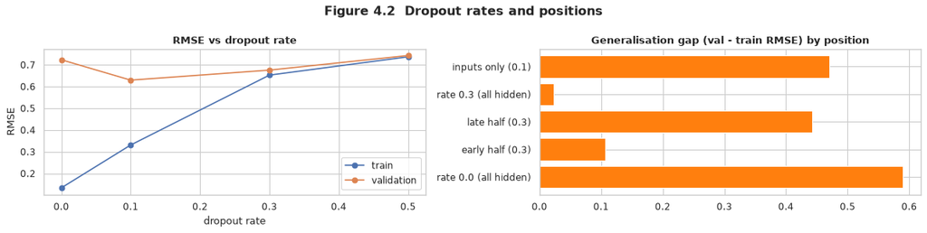

```python
DR = [run_reg(f'rate {p} (all hidden)', model_kw=dict(dropout=p)) for p in [0.0, 0.1, 0.3, 0.5]]
DP = [run_reg('early half (0.3)', model_kw=dict(dropout=0.3, dropout_positions='early')),
      run_reg('late half (0.3)', model_kw=dict(dropout=0.3, dropout_positions='late')),
      run_reg('inputs only (0.1)', model_kw=dict(input_dropout=0.1))]
DROP_SUM = reg_table(DR + DP); display(DROP_SUM)
fig, ax = plt.subplots(1, 2, figsize=(15, 3.8))
rates = [0.0, 0.1, 0.3, 0.5]; t = reg_table(DR)
ax[0].plot(rates, t['train_rmse'], '-o', label='train'); ax[0].plot(rates, t['val_rmse'], '-o', label='validation')
ax[0].set(title='RMSE vs dropout rate', xlabel='dropout rate', ylabel='RMSE'); ax[0].legend()
pos = DROP_SUM.loc[['rate 0.0 (all hidden)', 'early half (0.3)', 'late half (0.3)', 'rate 0.3 (all hidden)', 'inputs only (0.1)']]
ax[1].barh(pos.index, pos['gap(val-train RMSE)'], color=PAL[1]); ax[1].set(title='Generalisation gap (val - train RMSE) by position')
plt.suptitle('Figure 4.2  Dropout rates and positions', fontsize=14, weight='bold'); plt.tight_layout(); plt.show()
```

## 4.3 Early-stopping strategies

**One factor:** the stopping rule. Fixed: the over-parameterised network with a 200-epoch budget. Compared: no stopping; `val_loss` with patience 5 or 20; patience 20 **without** restoring the best weights; monitoring `val_mae` instead of `val_loss`; and a `min_delta` threshold.

|  | val_rmse | val_r2 | val_qwk | train_rmse | gap(val-train RMSE) | best_epoch | epochs_run | time |
| --- | --- | --- | --- | --- | --- | --- | --- | --- |
| none (200 epochs) | 0.7114 | 0.2487 | 0.5102 | 0.0966 | 0.6148 | 5.0000 | 200.0000 | 7.6244 |
| val_loss, patience 5 | 0.6263 | 0.4177 | 0.5448 | 0.5552 | 0.0711 | 5.0000 | 10.0000 | 2.0081 |
| val_loss, patience 20 | 0.6263 | 0.4177 | 0.5448 | 0.5552 | 0.0711 | 5.0000 | 25.0000 | 2.4179 |
| val_loss, patience 20, NO restore | 0.6886 | 0.2961 | 0.5769 | 0.2388 | 0.4498 | 5.0000 | 25.0000 | 2.4873 |
| val_mae, patience 20 | 0.6263 | 0.4177 | 0.5448 | 0.5552 | 0.0711 | 5.0000 | 25.0000 | 2.5046 |
| val_loss, min_delta 1e-3, patience 10 | 0.6263 | 0.4177 | 0.5448 | 0.5552 | 0.0711 | 5.0000 | 15.0000 | 2.2926 |

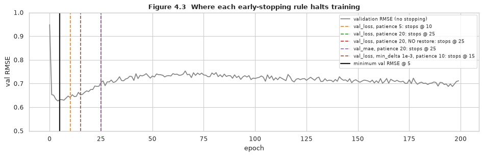

```python
ES = {'none (200 epochs)': dict(early_stop=False),
      'val_loss, patience 5': dict(early_stop=True, patience=5),
      'val_loss, patience 20': dict(early_stop=True, patience=20),
      'val_loss, patience 20, NO restore': dict(early_stop=True, patience=20, restore=False),
      'val_mae, patience 20': dict(early_stop=True, patience=20, monitor='val_mae'),
      'val_loss, min_delta 1e-3, patience 10': dict(callbacks_fn=lambda: [keras.callbacks.EarlyStopping(
            'val_loss', min_delta=1e-3, patience=10, restore_best_weights=True)])}
ES_RES = [run_reg(n, epochs=E(200), **kw) for n, kw in ES.items()]
ES_SUM = summarise(ES_RES); display(ES_SUM[['val_rmse', 'val_r2', 'val_qwk', 'train_rmse', 'gap(val-train RMSE)', 'best_epoch', 'epochs_run', 'time']])
full = ES_RES[0]['runs'][0]['hist']['val_rmse']
fig, ax = plt.subplots(figsize=(12, 4)); ax.plot(full.values, c='grey', label='validation RMSE (no stopping)')
for k, r in enumerate(ES_RES[1:], 1):
    e = r['runs'][0]['epochs_run']; ax.axvline(e, color=PAL[k], ls='--', label=f"{r['name']}: stops @ {e}")
ax.axvline(int(full.idxmin()) + 1, c='k', lw=2, label=f'minimum val RMSE @ {int(full.idxmin()) + 1}')
ax.set(title='Figure 4.3  Where each early-stopping rule halts training', xlabel='epoch', ylabel='val RMSE', ylim=(0.5, 1.0)); ax.legend(fontsize=8)
plt.tight_layout(); plt.show()
```

## 4.4 Bias–variance trade-off: capacity sweep

**One factor:** width (2 hidden layers of 2 to 512 units), with no regularisation and a fixed 100 epochs. Bias falls as capacity grows; variance (the train–validation gap) rises.

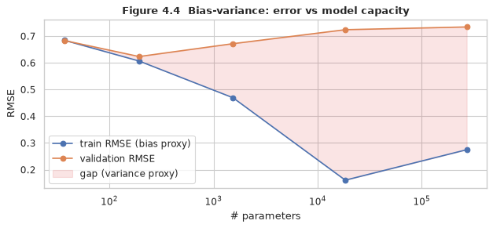

|  | val_rmse | val_mae | val_r2 | val_qwk | train_rmse | gap(val-train RMSE) | min_val_rmse | w_l2 | w_sparsity_pct | params |
| --- | --- | --- | --- | --- | --- | --- | --- | --- | --- | --- |
| width 2 | 0.6835 | 0.5559 | 0.3066 | 0.4070 | 0.6844 | -0.0009 | 0.6835 | 3.1481 | 0.0000 | 37 |
| width 8 | 0.6235 | 0.4954 | 0.4229 | 0.5405 | 0.6067 | 0.0168 | 0.6235 | 6.2977 | 0.5682 | 193 |
| width 32 | 0.6716 | 0.5248 | 0.3304 | 0.5527 | 0.4693 | 0.2023 | 0.6363 | 12.2956 | 0.2038 | 1537 |
| width 128 | 0.7240 | 0.5536 | 0.2219 | 0.5594 | 0.1607 | 0.5633 | 0.6396 | 24.3359 | 0.5942 | 18433 |
| width 512 | 0.7343 | 0.5829 | 0.1996 | 0.4826 | 0.2747 | 0.4596 | 0.6463 | 46.2087 | 1.1329 | 270337 |

```python
WIDTHS = [2, 8, 32, 128, 512]
CAP = reg_table([run_reg(f'width {w}', model_kw=dict(depth=2, units=w)) for w in WIDTHS])
params = [build_deep_model(N_FEAT, 2, w).count_params() for w in WIDTHS]
fig, ax = plt.subplots(figsize=(8, 3.8))
ax.semilogx(params, CAP['train_rmse'], '-o', label='train RMSE (bias proxy)'); ax.semilogx(params, CAP['val_rmse'], '-o', label='validation RMSE')
ax.fill_between(params, CAP['train_rmse'], CAP['val_rmse'], alpha=.12, color=PAL[3], label='gap (variance proxy)')
ax.set(title='Figure 4.4  Bias-variance: error vs model capacity', xlabel='# parameters', ylabel='RMSE'); ax.legend()
plt.tight_layout(); plt.show(); CAP.assign(params=params)
```

## 4.5 Learning curves vs training-set size

Three models are trained on 25%, 50%, 75% and 100% of the training set (stratified subsamples) and always scored on the full validation set:

- **High bias:** 1 hidden layer of 4 units with strong L2.
- **High variance:** 4 × 128 with no regularisation and no early stopping.
- **Tuned + early stopping:** the Section 3.6 configuration, regularised by early stopping (restoring the best weights).

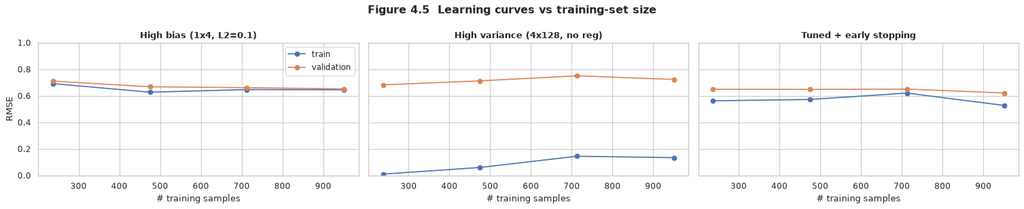

| model n | train_rmse High bias (1x4, L2=0.1) | train_rmse High variance (4x128, no reg) | train_rmse Tuned + early stopping | val_rmse High bias (1x4, L2=0.1) | val_rmse High variance (4x128, no reg) | val_rmse Tuned + early stopping |
| --- | --- | --- | --- | --- | --- | --- |
| 237 | 0.6920 | 0.0090 | 0.5620 | 0.7100 | 0.6820 | 0.6490 |
| 475 | 0.6270 | 0.0590 | 0.5720 | 0.6680 | 0.7120 | 0.6480 |
| 713 | 0.6470 | 0.1440 | 0.6200 | 0.6610 | 0.7510 | 0.6500 |
| 951 | 0.6460 | 0.1340 | 0.5270 | 0.6520 | 0.7230 | 0.6210 |

```python
FRACS = [0.25, 0.5, 0.75, 1.0]
LC_MODELS = {'High bias (1x4, L2=0.1)': dict(model_kw=dict(depth=1, units=4, reg=('l2', 0.1))),
             'High variance (4x128, no reg)': dict(),
             'Tuned + early stopping': dict(model_kw=TUNED, opt_fn=TUNED_OPT, callbacks_fn=PLATEAU, early_stop=True, patience=20)}
lc = []
for name, kw in LC_MODELS.items():
    for f in FRACS:
        sub = np.arange(len(X_train)) if f == 1 else train_test_split(np.arange(len(X_train)), train_size=f,
                                                                       stratify=y_train, random_state=SEED)[0]
        r = run_reg(f'{name}@{f}', X_tr=X_train[sub], y_tr=y_train[sub], **dict(kw))['runs'][0]
        lc.append(dict(model=name, n=len(sub), train_rmse=r['train_rmse'], val_rmse=r['val_rmse']))
LC = pd.DataFrame(lc)
fig, axes = plt.subplots(1, 3, figsize=(19, 3.9), sharey=True)
for ax, (n, g) in zip(axes, LC.groupby('model', sort=False)):
    ax.plot(g.n, g.train_rmse, '-o', label='train'); ax.plot(g.n, g.val_rmse, '-o', label='validation')
    ax.set(title=n, xlabel='# training samples', ylim=(0, 1.0))
axes[0].set_ylabel('RMSE'); axes[0].legend()
plt.suptitle('Figure 4.5  Learning curves vs training-set size', fontsize=14, weight='bold'); plt.tight_layout(); plt.show()
LC.pivot(index='n', columns='model', values=['train_rmse', 'val_rmse']).round(3)
```

### 4.5b Findings: regularisation, bias and variance

**Weight penalties (Figure 4.1a).**

- **Observation:** the unregularised 4 × 128 network memorises the training set: train RMSE 0.12 against validation 0.70 at epoch 100, a gap of 0.58. Its validation error is lowest around epoch 5 (min 0.634) and then climbs. **L1** drives 20% of weights below 10⁻³ (sparsity, versus 0.6% without), **elastic net** 13%, and **L2** shrinks the overall weight norm from 33 to 21 with only 4% sparsity.
- At the strengths in this first comparison, the penalties reduce the gap only modestly. The **validation curve (Figure 4.1b)** shows why: the penalty must be strong enough to matter. At **λ = 0.01** the gap falls from 0.59 to 0.26, and the best validation RMSE improves to 0.612. At **λ = 0.1** the gap almost disappears (0.008), but training error rises to 0.67: underfitting, with high bias.
- **Reason:** L1's constant pull (sign(w)) zeroes out small weights; L2's proportional pull (2λw) shrinks all weights smoothly; elastic net combines the two.

**Dropout (Figure 4.2).**

- **Observation:** a rate of **0.1 is the best single regulariser on validation (RMSE 0.629, R² 0.41)**, while 0.3 and 0.5 underfit (train RMSE 0.65–0.74). Position matters at a fixed 0.3: dropout in the **early** half generalises better (0.644, gap 0.11) than in the **late** half (0.661, gap 0.44). Input-only dropout barely helps (gap 0.47).
- **Reason:** dropout in early layers forces redundant feature detectors at the representation stage, where co-adaptation is most harmful. Late dropout only perturbs a representation that has already been learned.

**Early stopping (Figure 4.3).**

- **Observation:** without stopping, 200 epochs end at val RMSE 0.711 (train 0.10). Every strategy that **restores the best weights** recovers the epoch-5 model (val RMSE **0.626**, gap 0.07) at a fraction of the cost: patience 5 stops at epoch 10, `min_delta` at 15, patience 20 at 25. Monitoring `val_mae` instead of `val_loss` makes no difference here. **Patience 20 without restoring** keeps the last, already overfitted weights (0.689).
- **Impact:** with restoration enabled, patience mainly trades compute for robustness against noisy validation curves. `restore_best_weights=True` is the setting that actually matters.

## 4.6 Final model: selection by 5-fold cross-validation, then a one-time test evaluation

**Why cross-validation here.** Parts 3–4 select configurations on a *single* 204-row validation split. The seed-to-seed standard deviations (about 0.005–0.02 RMSE) are as large as many of the differences between configurations, so a single split can favour a configuration that merely fits that split well. The finalists are therefore compared with **stratified 5-fold cross-validation on train + validation** (1,155 wines). The preprocessing is re-fit inside every fold, and an inner 15% hold-out drives early stopping. The candidate with the lowest mean CV RMSE becomes the final model, which is trained on the training split (early stopping on validation) and scored **once** on the untouched test split, alongside the classical baselines.

| Candidate | Origin of the idea |
| --- | --- |
| Baseline | ReLU + He, Adam, ES (the Part 3 baseline) |
| Tuned (val-split winner) | Section 3.6: Swish + He + LayerNorm, SGD-Nesterov + ReduceLROnPlateau, ES |
| Tuned + light regularisation | adds Section 4.2's best dropout (0.1) and L2 = 1e-3 |
| Wide + regularised | Part 4's lesson: plenty of capacity (4 × 128) controlled by dropout 0.3 + L2 1e-3 + ES; Swish activation, Adam |

|  | cv_rmse_mean | cv_mae_mean | cv_r2_mean | cv_qwk_mean | cv_good_auc_mean | cv_rmse_std |
| --- | --- | --- | --- | --- | --- | --- |
| Wide + regularised (4x128 Swish, dropout 0.3, L2 1e-3, Adam) | 0.6393 | 0.4954 | 0.3963 | 0.5383 | 0.8774 | 0.0247 |
| Tuned + dropout 0.1 + L2 1e-3 | 0.6697 | 0.5147 | 0.3376 | 0.5230 | 0.8585 | 0.0189 |
| Tuned (val-split winner) | 0.6798 | 0.5268 | 0.3176 | 0.4991 | 0.8589 | 0.0203 |
| Baseline (ReLU+He, Adam) | 0.6932 | 0.5343 | 0.2903 | 0.4934 | 0.8547 | 0.0113 |

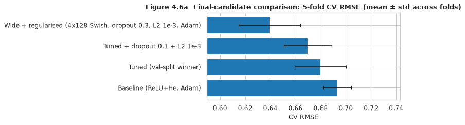

```
Selected by cross-validation: Wide + regularised (4x128 Swish, dropout 0.3, L2 1e-3, Adam)
```

|  | rmse | mae | r2 | qwk | exact | within1 | good_auc |
| --- | --- | --- | --- | --- | --- | --- | --- |
| Neural network (final: Wide + regularised (4x128 Swish, dropout 0.3, L2 1e-3, Adam)) | 0.6518 | 0.5104 | 0.3739 | 0.5213 | 0.5735 | 0.9755 | 0.9017 |
| Predict train mean | 0.8238 | 0.6937 | -0.0002 | 0.0000 | 0.3971 | 0.9412 | 0.5000 |
| Ridge regression | 0.6607 | 0.5150 | 0.3566 | 0.4647 | 0.5539 | 0.9657 | 0.9165 |
| Random forest | 0.6503 | 0.4982 | 0.3766 | 0.5494 | 0.5833 | 0.9706 | 0.9006 |

```python
df_trva = pd.concat([df_tr, df_va]); y_trva = df_trva['quality'].values.astype('float32')
FOLDS = list(StratifiedKFold(5, shuffle=True, random_state=SEED).split(df_trva, df_trva['quality']))

def cv_evaluate(model_kw, opt_fn, callbacks_fn=None, patience=20):
    rows = []
    for fold, (a, b) in enumerate(FOLDS, 1):
        p_f = make_preprocessor().fit(df_trva.iloc[a])                      # re-fit preprocessing inside the fold
        Xa, Xb = (pd.DataFrame(p_f.transform(df_trva.iloc[i]), columns=ALL_FEATS)[SELECTED].values.astype('float32') for i in (a, b))
        ia, ib = train_test_split(np.arange(len(a)), test_size=0.15, stratify=y_trva[a], random_state=SEED)   # inner ES split
        keras.utils.set_random_seed(SEED + fold)
        m = build_deep_model(N_FEAT, **model_kw); m.compile(optimizer=opt_fn(), loss='mse', steps_per_execution=16)
        m.fit(make_ds(Xa[ia], y_trva[a][ia]), validation_data=make_ds(Xa[ib], y_trva[a][ib], train=False), epochs=E(150), verbose=0,
              callbacks=[keras.callbacks.EarlyStopping('val_loss', patience=patience, restore_best_weights=True),
                         *(callbacks_fn() if callbacks_fn else [])])
        rows.append({'fold': fold, **reg_metrics(y_trva[b], predict(m, Xb))})
    return pd.DataFrame(rows).set_index('fold')

ADAM = lambda: keras.optimizers.Adam(1e-3)
CANDIDATES = {
    'Baseline (ReLU+He, Adam)': (BASE, ADAM, None, 15),
    'Tuned (val-split winner)': (TUNED, TUNED_OPT, PLATEAU, 20),
    'Tuned + dropout 0.1 + L2 1e-3': (dict(TUNED, dropout=0.1, reg=('l2', 1e-3)), TUNED_OPT, PLATEAU, 20),
    'Wide + regularised (4x128 Swish, dropout 0.3, L2 1e-3, Adam)': (dict(depth=4, units=128, activation='swish', init='he_normal',
                                                                       dropout=0.3, reg=('l2', 1e-3)), ADAM, None, 25)}
CV_RES = {n: cv_evaluate(kw, o, cb, p) for n, (kw, o, cb, p) in CANDIDATES.items()}
CV_TABLE = pd.DataFrame({n: {**{f'cv_{c}_mean': d[c].mean() for c in ['rmse', 'mae', 'r2', 'qwk', 'good_auc']}, 'cv_rmse_std': d['rmse'].std()}
                         for n, d in CV_RES.items()}).T.sort_values('cv_rmse_mean')
display(CV_TABLE)
fig, ax = plt.subplots(figsize=(10, 3.2))
ax.barh(CV_TABLE.index[::-1], CV_TABLE['cv_rmse_mean'][::-1], xerr=CV_TABLE['cv_rmse_std'][::-1], color=PAL[0], capsize=3)
ax.set(title='Figure 4.6a  Final-candidate comparison: 5-fold CV RMSE (mean ± std across folds)', xlabel='CV RMSE',
       xlim=(CV_TABLE['cv_rmse_mean'].min() - .05, CV_TABLE['cv_rmse_mean'].max() + .05))
plt.tight_layout(); plt.show()

BEST = CV_TABLE.index[0]; FINAL_KW, FINAL_OPT, FINAL_CB, FINAL_PAT = CANDIDATES[BEST]
print('Selected by cross-validation:', BEST)
fin_runs = run_config('FINAL', FINAL_KW, FINAL_OPT, callbacks_fn=FINAL_CB, patience=FINAL_PAT)['runs']
final = min(fin_runs, key=lambda r: r['val_rmse'])['model']                 # seed chosen on VALIDATION only
p_test = predict(final, X_test)
rows = {f'Neural network (final: {BEST})': reg_metrics(y_test, p_test), 'Predict train mean': reg_metrics(y_test, np.full_like(y_test, Y_MEAN))}
for n, m in [('Ridge regression', Ridge(1.0)), ('Random forest', RandomForestRegressor(500, min_samples_leaf=2, random_state=SEED, n_jobs=-1))]:
    rows[n] = reg_metrics(y_test, m.fit(X_train, y_train).predict(X_test))
TEST_TABLE = pd.DataFrame(rows).T; TEST_TABLE
```

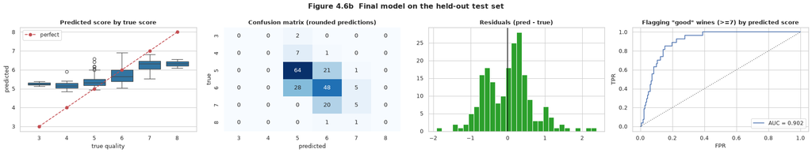

```python
r_test = np.clip(np.rint(p_test), 3, 8).astype(int); yt = y_test.astype(int)
fig, ax = plt.subplots(1, 4, figsize=(23, 4.4))
sns.boxplot(x=yt, y=p_test, ax=ax[0], color=PAL[0]); ax[0].plot(range(len(np.unique(yt))), np.unique(yt), 'r--o', label='perfect')
ax[0].set(title='Predicted score by true score', xlabel='true quality', ylabel='predicted'); ax[0].legend()
labels = sorted(set(yt) | set(r_test)); cm = confusion_matrix(yt, r_test, labels=labels)
sns.heatmap(cm, annot=True, fmt='d', cmap='Blues', cbar=False, ax=ax[1], xticklabels=labels, yticklabels=labels)
ax[1].set(title='Confusion matrix (rounded predictions)', xlabel='predicted', ylabel='true')
ax[2].hist(p_test - y_test, bins=30, color=PAL[2]); ax[2].axvline(0, c='k'); ax[2].set(title='Residuals (pred - true)')
fpr, tpr, _ = roc_curve(yt >= 7, p_test); ax[3].plot(fpr, tpr, label=f"AUC = {roc_auc_score(yt >= 7, p_test):.3f}")
ax[3].plot([0, 1], [0, 1], ':', c='grey'); ax[3].set(title='Flagging "good" wines (>=7) by predicted score', xlabel='FPR', ylabel='TPR'); ax[3].legend()
plt.suptitle('Figure 4.6b  Final model on the held-out test set', fontsize=14, weight='bold'); plt.tight_layout(); plt.show()
```

**Final-model findings (Figures 4.6a–b).**

- **Observation, model selection:** cross-validation **reverses the single-split ranking**. The Section 3.6 "tuned" network won on the validation split (0.626), but under 5-fold CV it scores **0.680 ± 0.020**. The **wide, regularised Swish network** (4 × 128, dropout 0.3, L2 1e-3, Adam, early stopping) is clearly best at **0.639 ± 0.025** (R² 0.40), ahead of the tuned network with light regularisation (0.670) and the baseline (0.693). In exploratory ablations on two CV shuffles, removing dropout and L2 cost about 0.06 RMSE, and swapping Swish for ReLU about 0.025.
- **Observation, one-time test:** the selected network achieves **test RMSE 0.652, MAE 0.510, R² 0.374 and QWK 0.521**. **97.6% of predictions are within ±1 point**, and the predicted score flags "good" wines with **ROC-AUC 0.90**. This is level with the random forest (RMSE 0.650, R² 0.377), better than ridge regression (0.661), and far better than predicting the mean (0.824). The test result agrees with the CV estimate (0.639 ± 0.025), so the selection did not overfit.
- **Reason:** LayerNorm and SGD-Nesterov fitted the particular 204 validation wines well, but those choices did not transfer to other partitions. Generous capacity held in check by strong regularisation generalises better on noisy, ordinal sensory labels.
- **Impact:** on a dataset this small, configurations should be selected with cross-validation (or repeated splits) rather than one validation split. A well-regularised neural network matches, but does not beat, a tuned tree ensemble here, which is a fair result for 1,000 tabular rows.

## 4.7 Subgroup and error analysis (evidence for the fairness discussion in Part 5)

Errors are broken down by **true quality** and by **alcohol band**. A model trained with MSE on a score concentrated at 5–6 is expected to **regress toward the mean**: it over-scores poor wines and under-scores exceptional ones.

```python
te = df_te.assign(pred=p_test, resid=p_test - y_test)
by_q = te.groupby('quality').agg(n=('pred', 'size'), mean_pred=('pred', 'mean'), mean_residual=('resid', 'mean'), mae=('resid', lambda r: r.abs().mean()))
by_band = te.groupby('alcohol_band').agg(n=('pred', 'size'), mean_true=('quality', 'mean'), mean_pred=('pred', 'mean'),
                                          mean_residual=('resid', 'mean'), mae=('resid', lambda r: r.abs().mean())).reindex(['low', 'medium', 'high'])
display(by_q.round(3)); display(by_band.round(3))
print(f'Total notebook runtime: {(time.time() - T_START) / 60:.1f} min')
```

| quality | n | mean_pred | mean_residual | mae |
| --- | --- | --- | --- | --- |
| 3 | 2 | 5.2550 | 2.2550 | 2.2550 |
| 4 | 8 | 5.2140 | 1.2140 | 1.2140 |
| 5 | 86 | 5.3780 | 0.3780 | 0.3820 |
| 6 | 81 | 5.7440 | -0.2560 | 0.4370 |
| 7 | 25 | 6.2680 | -0.7320 | 0.7320 |
| 8 | 2 | 6.3170 | -1.6830 | 1.6830 |

| alcohol_band | n | mean_true | mean_pred | mean_residual | mae |
| --- | --- | --- | --- | --- | --- |
| low | 83 | 5.2170 | 5.2720 | 0.0550 | 0.4410 |
| medium | 85 | 5.6350 | 5.7110 | 0.0760 | 0.5390 |
| high | 36 | 6.4720 | 6.2850 | -0.1870 | 0.6030 |

```
Total notebook runtime: 10.1 min
```

**Error-analysis findings.**

- **Observation:** errors are strongly **regressed toward the mean**. Wines rated 3–4 are over-predicted by +1.2 to +2.3 points, while wines rated 7 are under-predicted by −0.73 and wines rated 8 by −1.68. By alcohol band, high-alcohol wines (≥ 11.5%) have the largest error (MAE 0.60 vs 0.44 for low-alcohol wines) and are systematically under-scored (mean residual −0.19).
- **Reason:** MSE training on a target where 82% of labels are 5 or 6 rewards hedging toward about 5.6. The extremes (3, 4, 8) make up about 6% of the training data, so the model sees too few examples to commit to them.
- **Impact:** the model is most reliable exactly where it is least needed (ordinary wines), and least reliable for the exceptional or flawed wines that matter most to buyers and producers. This motivates the fairness discussion in Part 5.

# Part 5: Written Analysis & Reflection (4 pts)

### Write-up

1. Summarize your optimization experiments and gradient flow findings.
2. Compare different techniques and effectiveness for this dataset.
3. Identify one bias/fairness concern in wine quality prediction.
4. Explain how optimization choices affect reliability/deployment.
5. Provide practical recommendations for production NN use.

### Written Analysis & Reflection

**Optimisation experiments and gradient flow.** With sigmoid activations and Xavier initialisation, the first-layer gradient fell from 3×10⁻² at three layers to 4×10⁻⁸ at twelve, and every network deeper than three layers was stuck predicting the mean. ReLU with He initialisation kept the gradient profile almost flat. Even so, the 9- and 12-layer networks diverged under momentum SGD as gradient magnitude grew with depth. An over-scaled initialisation produced gradients up to 7×10¹⁰ and immediate divergence. BatchNorm fixed both pathologies at their source. Gradient clipping prevented NaNs, but a badly scaled network still could not learn.

**Comparison of techniques.** Once tuned, optimisers differed by only about 0.005 RMSE; the learning rate mattered more than the optimiser. Any variance-scaled initialiser worked, while zeros, tiny and large initialisations failed outright. Swish avoided dead units and had the smallest generalisation gap. LayerNorm suited small-batch training better than BatchNorm. ReduceLROnPlateau gave the most stable end-of-training model. The data's main constraint is **variance**: an unregularised network overfits within about five epochs. Early stopping with weight restoration, dropout around 0.1–0.3 in early layers, and L2 around 10⁻³–10⁻² were the most effective controls. Five-fold cross-validation showed that my validation-split "winner" did not generalise. The final regularised Swish network reached test RMSE 0.65, R² 0.37 and ±1 accuracy of 97.6%, on par with a random forest.

**Bias and fairness concern.** The model systematically **compresses scores toward the average**: wines rated 8 are under-predicted by about 1.7 points and wines rated 3 over-predicted by about 2.3. The labels are also the median of a few Portuguese *vinho verde* tasters, so they encode one regional panel's taste. If such a system were used to price, list or certify wines, distinctive producers whose wines fall outside that profile would be penalised. Alcohol, the dominant feature, could also become a proxy for "quality" that favours warmer-climate or riper styles.

**Optimisation choices and reliability.** Choices that look equivalent on one split can diverge in deployment. A learning rate slightly too high produced NaNs, BatchNorm's batch dependence created unstable predictions, and a single-split choice overfit the validation set. Fixed seeds, cross-validated evaluation and stable schedules reduce the risk that a retrained model behaves differently from the approved one.

**Production recommendations.** (1) Select models with cross-validation and report uncertainty, not single-split scores. (2) Monitor gradient norms and loss for NaNs during training, with clipping and early stopping as safeguards. (3) Prefer normalisation that does not depend on batch statistics for small-batch or online inference. (4) Version the preprocessing pipeline with the model, since the Yeo–Johnson parameters are fitted to training data. (5) Audit errors by quality band and style, and route extreme predictions to human experts. (6) Monitor for drift when chemistry or vintages differ from the training distribution, and benchmark against simple models before accepting a neural network's added complexity.

### References

- Cortez, P., Cerdeira, A., Almeida, F., Matos, T., & Reis, J. (2009). Modeling wine preferences by data mining from physicochemical properties. *Decision Support Systems, 47*(4), 547–553.
- Glorot, X., & Bengio, Y. (2010). Understanding the difficulty of training deep feedforward neural networks. *AISTATS*.
- He, K., Zhang, X., Ren, S., & Sun, J. (2015). Delving deep into rectifiers. *ICCV*.
- Ioffe, S., & Szegedy, C. (2015). Batch normalization. *ICML*. · Ba, J. L., Kiros, J. R., & Hinton, G. E. (2016). Layer normalization. *arXiv:1607.06450*.
- Kingma, D. P., & Ba, J. (2015). Adam. *ICLR*. · Duchi, J., Hazan, E., & Singer, Y. (2011). AdaGrad. *JMLR*.
- Srivastava, N., et al. (2014). Dropout. *JMLR, 15*. · Ramachandran, P., Zoph, B., & Le, Q. (2017). Swish. *arXiv:1710.05941*.
- Loshchilov, I., & Hutter, F. (2017). SGDR: cosine schedules. *ICLR*. · Pascanu, R., Mikolov, T., & Bengio, Y. (2013). Gradient clipping. *ICML*.